# Exercise - Dose-Response Relations

Marc A.T. Teunis

2019-04-05

```r
library(tidyverse)
library(drc)
# ??drc
```

**Write an Rmd file, containing code chunks (if applicable) and answer all the questions below. Store the file in a folder called: “./answers_exercises” in your course project folder. Give this file the same name as the title of the current Rmd file**

## Dose response relations

Dose response relations are a much modelled experimental paradigm in Life Sciences. In drug discovery, safety evaluation of chemicals, drugs and food, in fundamental approaches like cell culture and tissue culture and also in animal research, this is a see much used experimental design. Usually, the design is chosen where an effector (for example a carcinogenic drug) is used to expose a biological response model (in this case e.g. a live rat or a cultured cell)

## The exercise

This exercise will get you acquainted with the `drc` package in R and you will have to apply this package to an example (real-life) dataset.

## The {drc} package

The `drc` package has been developed and is maintained by Ritz & Strebig and has been published in PLOS-One and the Journal of Statitical Software (see folder `./data/supporting`)

## The Data

Two different datasets from two publications are used for this exercise and were selected from a study of Allijn et al., 2016 and from Teunis et., 2013

The data can ben found as two seprate files in the folder `./data`:

1. Allijn et al., 2016 -> `./data/allijn.csv`
2. Teunis et., 2013 -> `./data/NCTC data all participants.xlsx`

## Exercise 1: Allijn et al., 2016

1A Read the data into R, use the package `readr` to do this.

**ANSWER**

```r
#install.packages("devtools")
#library(devtools)
#install_github("bkutlu/pzfxparser")


path_to_allijn <- file.path(root, "data", "allijn.txt")
allijn <- read_delim(file = path_to_allijn, delim = ";")
```

1B Inspect the data and create a tidy dataset from the original data:

- Describe the variables
- Are there factors that need to be transformed?
- Do the factor levels match?
- Is the coding consistent?
- Do you need to `gather()` or `spread()`?

**ANSWER**

1C Normalize the data for the respective controls of each `substance` in the dataset

1D Create a series of dose response plots. Create aplot for each`substance` and for each `effect`

## Exercise 2: Teunis et al., 2013

The data path: `file.path(root, "data", "NCTC compounds corrected 20121013_decoded.csv")`

2A Read the data into R, use the package `readxl` to do this.

The datafile consists of multiple worksheets. Inpect the data manually by opening the data in Excel. Load the sheet names “Compound NCTC”. This worksheet contains collected data from all the experiments. Remove the first two rows of the datatable after parsing of the Excel file

**TIPS**

- Inspect the csv, do you need to set the `na = c()` parameter in the `read_csv()` function to something other than the default?

**ANSWER**

```r
path_to_teunis <- file.path(root, "data", "NCTC compounds corrected 20121013_decoded.csv")
teunis <- readr::read_delim(file = path_to_teunis, delim = ";")
teunis
```

```
## # A tibble: 9,296 x 14
##      Lab Chemical Compound Category Exp      c1    c2 Conc.   Rep valid
##    <dbl> <chr>       <dbl> <chr>    <chr> <dbl> <dbl> <dbl> <dbl> <chr>
##  1     1 Toluene~        1 N        1       1.1   1.1   125     1 Yes
##  2     1 Toluene~        1 N        1       1.1   1.1   125     2 Yes
##  3     1 Toluene~        1 N        1       1.1   1.1   125     3 Yes
##  4     1 Toluene~        1 N        1       1.1   1.1   125     4 Yes
##  5     1 Toluene~        1 N        1       1.2   1.1   250     1 Yes
##  6     1 Toluene~        1 N        1       1.2   1.1   250     2 Yes
##  7     1 Toluene~        1 N        1       1.2   1.1   250     3 Yes
##  8     1 Toluene~        1 N        1       1.2   1.1   250     4 Yes
##  9     1 Toluene~        1 N        1       1.3   1.1   500     1 Yes
## 10     1 Toluene~        1 N        1       1.3   1.1   500     2 Yes
## # ... with 9,286 more rows, and 4 more variables: Viability <dbl>,
## #   `IL-18` <dbl>, FI <dbl>, Dunnett <chr>
```

### Variables

The variables that need te be selected in this dataset:

Lab, Chemical, Compound, Category, Exp, c1, c2, Conc., Rep, valid, Viability, IL-18, FI, Dunnett

- `Lab` = the lab the compound was tested in
- `Chemical` = the name of the compound
- `Category` = the chemical class that is known for the chemical
- `Exp` = experimental replicate (between experiments)
- `Conc.` = the concentration of the compound that was used
- `Rep` = replicates (within experiments)
- `Viability` = dependent variable: survival of cells based on MTT conversion (% compared to vehicle control)
- `IL-18` = dependent variable: The absolute concentration of IL-18 cytokine measured in the medium with ELISA (pg/ml)
- `FI` = fold induction of IL-18 cytokine, compared to vehicle control

**TIPS**

- Use `dplyr::select`
- Use `names(df) <- names(df) %>% tolower`
- Use `names(df) <- stringr::replace_all(string = names(df),` `pattern = ...,` `replacement = ...)`
- Try cleaning up the `names` with one pipeline using `%>%`
- Rember that you can use `.` as placeholder for the data/vector/table that you put into the pipe
- Check for missing values(NA) or infinites values (Inf / NaN) and remove them from the tidy dataset

2B Inspect the data and create a tidy dataset from the original data:

- Are there factor (grouping) variables that need to be transformed?
- Do the factor levels match?
- Is the coding consistent?
- Do you need to `gather()` or `spread()`?
- count NAs and remove them

**ANSWER**

```r
names(teunis)
```

```
##  [1] "Lab"       "Chemical"  "Compound"  "Category"  "Exp"
##  [6] "c1"        "c2"        "Conc."     "Rep"       "valid"
## [11] "Viability" "IL-18"     "FI"        "Dunnett"
```

```r
teunis_tidy <- teunis %>%
  dplyr::select(-c1, -c2, -valid, -Dunnett, -Compound)

names(teunis_tidy) <- names(teunis_tidy) %>%

                      str_replace_all(string = .,            # dot (.) = placeholder for                                                                   # names(teunis_tidy)
                                      pattern = "\\.",
                                      replacement = "") %>%

                      str_replace_all(string = .,
                                      pattern = "-",
                                      replacement = "_") %>%
  tolower() %>%
  print()
```

```
## [1] "lab"       "chemical"  "category"  "exp"       "conc"      "rep"
## [7] "viability" "il_18"     "fi"
```

```r
sum(is.na(teunis_tidy))
```

```
## [1] 142
```

```r
teunis_tidy <- teunis_tidy %>% na.omit()
teunis_tidy
```

```
## # A tibble: 9,168 x 9
##      lab chemical          category exp    conc   rep viability il_18    fi
##    <dbl> <chr>             <chr>    <chr> <dbl> <dbl>     <dbl> <dbl> <dbl>
##  1     1 Toluene disicyan~ N        1       125     1      99.1  21.9 0.969
##  2     1 Toluene disicyan~ N        1       125     2      90.1  20.5 0.906
##  3     1 Toluene disicyan~ N        1       125     3      99.0  21.1 0.932
##  4     1 Toluene disicyan~ N        1       125     4      94.6  23.3 1.03
##  5     1 Toluene disicyan~ N        1       250     1      77.3  19.6 0.867
##  6     1 Toluene disicyan~ N        1       250     2      76.5  22.1 0.977
##  7     1 Toluene disicyan~ N        1       250     3      89.2  22.8 1.01
##  8     1 Toluene disicyan~ N        1       250     4      91.5  23.8 1.05
##  9     1 Toluene disicyan~ N        1       500     1      68.5  20.0 0.883
## 10     1 Toluene disicyan~ N        1       500     2      68    21.4 0.947
## # ... with 9,158 more rows
```

```r
teunis_tidy$lab <- as.factor(teunis_tidy$lab)
#teunis_tidy$chemical <- as.factor(teunis_tidy$chemical)
teunis_tidy$exp <- as.factor(teunis_tidy$exp)
#teunis_tidy$conc <- as.numeric(teunis_tidy$conc)
#teunis_tidy$viability <- as.numeric(teunis_tidy$viability)
#teunis_tidy$il_18 <- as.numeric(teunis_tidy$il_18)
#teunis_tidy$fold <- as.numeric(teunis_tidy$fold)

## convert lab, compound, exp and rep to factors and conc, viability, il_18 and fold
teunis_tidy
```

```
## # A tibble: 9,168 x 9
##    lab   chemical          category exp    conc   rep viability il_18    fi
##    <fct> <chr>             <chr>    <fct> <dbl> <dbl>     <dbl> <dbl> <dbl>
##  1 1     Toluene disicyan~ N        1       125     1      99.1  21.9 0.969
##  2 1     Toluene disicyan~ N        1       125     2      90.1  20.5 0.906
##  3 1     Toluene disicyan~ N        1       125     3      99.0  21.1 0.932
##  4 1     Toluene disicyan~ N        1       125     4      94.6  23.3 1.03
##  5 1     Toluene disicyan~ N        1       250     1      77.3  19.6 0.867
##  6 1     Toluene disicyan~ N        1       250     2      76.5  22.1 0.977
##  7 1     Toluene disicyan~ N        1       250     3      89.2  22.8 1.01
##  8 1     Toluene disicyan~ N        1       250     4      91.5  23.8 1.05
##  9 1     Toluene disicyan~ N        1       500     1      68.5  20.0 0.883
## 10 1     Toluene disicyan~ N        1       500     2      68    21.4 0.947
## # ... with 9,158 more rows
```

2C Which chemicals have (on average), a fold-increase in IL-18 induction of > 2.5? Which 4 have a fi < 0.7?

**TIPS**

- Use `dplyr::group_by()`
- Summarize the data per compound, first for all replicates within experiments, than for all experiments per compound.
- You will need `dplyr::mutate()` to change the type of the dependent vars
- You will need `dplyr::summarise()` to create the summary table
- Include a variable `overall_mean_fold`, `overall_sd_fold` and `overall_n_fold`
- You will need `dplyr::arrange()` to get the highest and lowest 4.

**ANSWER**

```r
teunis_tidy
```

```
## # A tibble: 9,168 x 9
##    lab   chemical          category exp    conc   rep viability il_18    fi
##    <fct> <chr>             <chr>    <fct> <dbl> <dbl>     <dbl> <dbl> <dbl>
##  1 1     Toluene disicyan~ N        1       125     1      99.1  21.9 0.969
##  2 1     Toluene disicyan~ N        1       125     2      90.1  20.5 0.906
##  3 1     Toluene disicyan~ N        1       125     3      99.0  21.1 0.932
##  4 1     Toluene disicyan~ N        1       125     4      94.6  23.3 1.03
##  5 1     Toluene disicyan~ N        1       250     1      77.3  19.6 0.867
##  6 1     Toluene disicyan~ N        1       250     2      76.5  22.1 0.977
##  7 1     Toluene disicyan~ N        1       250     3      89.2  22.8 1.01
##  8 1     Toluene disicyan~ N        1       250     4      91.5  23.8 1.05
##  9 1     Toluene disicyan~ N        1       500     1      68.5  20.0 0.883
## 10 1     Toluene disicyan~ N        1       500     2      68    21.4 0.947
## # ... with 9,158 more rows
```

```r
names(teunis_tidy)
```

```
## [1] "lab"       "chemical"  "category"  "exp"       "conc"      "rep"
## [7] "viability" "il_18"     "fi"
```

```r
teunis_summary <- teunis_tidy %>%
  group_by(chemical, exp, conc, category) %>%
#  mutate(viability = as.numeric(viability), # fix type of numeric vars
#         il_18 = as.numeric(il_18),
#         fold = as.numeric(fi)) %>%
  summarise(mean_viability = mean(viability),
            mean_fi = mean(fi),
            mean_il_18 = mean(il_18)) %>%
  group_by(chemical, conc, category) %>%
  summarise(overall_mean_fi = mean(mean_fi),
            overall_sd_fold = sd(mean_fi),
            overall_mean_viability = mean(mean_viability),
            overall_mean_il_18 = mean(mean_il_18),
            overall_n_fi = n()) %>%
  arrange(desc(overall_mean_fi))

teunis_summary
```

```
## # A tibble: 535 x 8
## # Groups:   chemical, conc [535]
##    chemical   conc category overall_mean_fi overall_sd_fold
##    <chr>     <dbl> <chr>              <dbl>           <dbl>
##  1 Hexamet~  260   N                   4.52          6.48
##  2 Hexamet~  130   N                   4.04          4.43
##  3 Methyl ~ 1000   N                   4.00          5.87
##  4 1-chlor~   10   Y                   3.45          2.59
##  5 p-Pheny~   90   Y                   2.66          0.0440
##  6 p-Pheny~   45   Y                   2.46          0.194
##  7 Tween 80  300   N                   2.29          1.48
##  8 Hexamet~   65   N                   2.04          1.29
##  9 1-chlor~    3   Y                   1.96          0.267
## 10 p-Pheny~   22.5 Y                   1.93          0.0648
## # ... with 525 more rows, and 3 more variables:
## #   overall_mean_viability <dbl>, overall_mean_il_18 <dbl>,
## #   overall_n_fi <int>
```

```r
min(teunis_summary$overall_mean_fi)
```

```
## [1] -0.41475
```

```r
max(teunis_summary$overall_mean_fi)
```

```
## [1] 4.523306
```

```r
teunis_summary %>% is.na %>% sum()
```

```
## [1] 1
```

```r
# highest fi:
highest_fold <- teunis_summary %>%
  filter(overall_mean_fi > 2.5)

# lowest fi:
lowest_fold <- teunis_summary %>%
  filter(overall_mean_fi < 0.7 )

highest_fold <- highest_fold$chemical %>% unique()
## 4 lowest
lowest_fold <- lowest_fold$chemical %>% unique()

highest_fold
```

```
## [1] "Hexamethylene diisocyanate" "Methyl salicylate"
## [3] "1-chloro-2,4-dinitrobezene" "p-Phenylenediamine"
```

```r
lowest_fold
```

```
## [1] "Benzocaine"                 "Hexachloroplatinate"
## [3] "Hexamethylene diisocyanate" "Trimellitic anhydride"
## [5] "Zinc sulphate"
```

```r
teunis_summary
```

```
## # A tibble: 535 x 8
## # Groups:   chemical, conc [535]
##    chemical   conc category overall_mean_fi overall_sd_fold
##    <chr>     <dbl> <chr>              <dbl>           <dbl>
##  1 Hexamet~  260   N                   4.52          6.48
##  2 Hexamet~  130   N                   4.04          4.43
##  3 Methyl ~ 1000   N                   4.00          5.87
##  4 1-chlor~   10   Y                   3.45          2.59
##  5 p-Pheny~   90   Y                   2.66          0.0440
##  6 p-Pheny~   45   Y                   2.46          0.194
##  7 Tween 80  300   N                   2.29          1.48
##  8 Hexamet~   65   N                   2.04          1.29
##  9 1-chlor~    3   Y                   1.96          0.267
## 10 p-Pheny~   22.5 Y                   1.93          0.0648
## # ... with 525 more rows, and 3 more variables:
## #   overall_mean_viability <dbl>, overall_mean_il_18 <dbl>,
## #   overall_n_fi <int>
```

How come that there are doubles in both low and high induction?

2D Create a subset of the `teunis_summary` data on the basis of the 8 chemicals selected above `teunis_subset`

**TIPS**

- Use `dplyr::filter()`

**ANSWER**

```r
teunis_subset_summary <- teunis_summary %>%
  filter(chemical %in% c(highest_fold, lowest_fold))

## check if it went okay:
levels(droplevels(as.factor(teunis_subset_summary$chemical)))
```

```
## [1] "1-chloro-2,4-dinitrobezene" "Benzocaine"
## [3] "Hexachloroplatinate"        "Hexamethylene diisocyanate"
## [5] "Methyl salicylate"          "p-Phenylenediamine"
## [7] "Trimellitic anhydride"      "Zinc sulphate"
```

**TIPS**

- Remember ggplot2 `geom_point()`?
- Remember `facet_wrap`?

**ANSWER**

Dot Plot

```r
teunis_subset_summary
```

```
## # A tibble: 136 x 8
## # Groups:   chemical, conc [136]
##    chemical   conc category overall_mean_fi overall_sd_fold
##    <chr>     <dbl> <chr>              <dbl>           <dbl>
##  1 Hexamet~  260   N                   4.52          6.48
##  2 Hexamet~  130   N                   4.04          4.43
##  3 Methyl ~ 1000   N                   4.00          5.87
##  4 1-chlor~   10   Y                   3.45          2.59
##  5 p-Pheny~   90   Y                   2.66          0.0440
##  6 p-Pheny~   45   Y                   2.46          0.194
##  7 Hexamet~   65   N                   2.04          1.29
##  8 1-chlor~    3   Y                   1.96          0.267
##  9 p-Pheny~   22.5 Y                   1.93          0.0648
## 10 p-Pheny~   40   Y                   1.83          0.348
## # ... with 126 more rows, and 3 more variables:
## #   overall_mean_viability <dbl>, overall_mean_il_18 <dbl>,
## #   overall_n_fi <int>
```

```r
teunis_subset_summary %>%
  arrange(overall_mean_viability) %>%
  na.omit()
```

```
## # A tibble: 136 x 8
## # Groups:   chemical, conc [136]
##    chemical  conc category overall_mean_fi overall_sd_fold overall_mean_vi~
##    <chr>    <dbl> <chr>              <dbl>           <dbl>            <dbl>
##  1 1-chlor~    10 Y                  3.45           2.59               30.5
##  2 Zinc su~   340 N                 -0.415          1.20               37.2
##  3 Hexachl~    50 N                  0.692          0.277              51.2
##  4 p-Pheny~   112 Y                  1.05           0.583              61.5
##  5 p-Pheny~    90 Y                  2.66           0.0440             64.1
##  6 Benzoca~   500 Y                  0.813          0.166              70.1
##  7 1-chlor~     5 Y                  1.68           0.479              73.4
##  8 1-chlor~    50 Y                  1.15           0.0201             74.8
##  9 Hexamet~   260 N                  4.52           6.48               75.0
## 10 Hexamet~   250 N                  1.27           0.233              75.7
## # ... with 126 more rows, and 2 more variables: overall_mean_il_18 <dbl>,
## #   overall_n_fi <int>
```

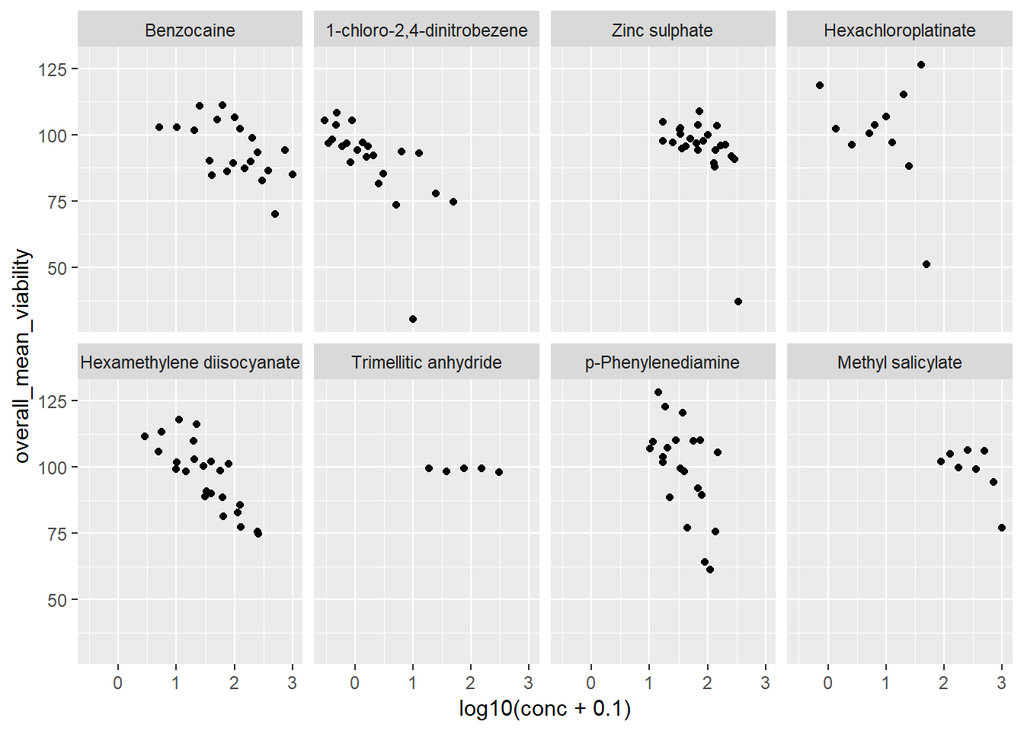

```r
teunis_subset_summary$conc <- as.numeric(teunis_subset_summary$conc)

teunis_subset_summary %>%
  arrange(overall_mean_il_18) %>%
  ggplot(aes(x = log10(conc+0.1), y = overall_mean_viability)) +
    geom_point() +
  facet_wrap(~ fct_reorder(chemical, overall_mean_il_18), nrow = 2)
```

What do you notice from the order?

# The drc package

The drc package can be loaded by `library(drc)`. Find help by typing `?drc`.

For the exercises below you need to create a new dataset (`teunis_drc`) that summarizes the data for each within-experiment replicate. Group the data for `chemical, exp, conc and category`.

**TIPS**

- Group by compound, exp, category and conc
- We add 0.1 to each concnetration and take log10, this will be our ‘log10’ transformed values (log10(0) = Inf, so we tackle this problem by adding 0.1 to each value)

```r
names(teunis_tidy)
```

```
## [1] "lab"       "chemical"  "category"  "exp"       "conc"      "rep"
## [7] "viability" "il_18"     "fi"
```

```r
teunis_tidy
```

```
## # A tibble: 9,168 x 9
##    lab   chemical          category exp    conc   rep viability il_18    fi
##    <fct> <chr>             <chr>    <fct> <dbl> <dbl>     <dbl> <dbl> <dbl>
##  1 1     Toluene disicyan~ N        1       125     1      99.1  21.9 0.969
##  2 1     Toluene disicyan~ N        1       125     2      90.1  20.5 0.906
##  3 1     Toluene disicyan~ N        1       125     3      99.0  21.1 0.932
##  4 1     Toluene disicyan~ N        1       125     4      94.6  23.3 1.03
##  5 1     Toluene disicyan~ N        1       250     1      77.3  19.6 0.867
##  6 1     Toluene disicyan~ N        1       250     2      76.5  22.1 0.977
##  7 1     Toluene disicyan~ N        1       250     3      89.2  22.8 1.01
##  8 1     Toluene disicyan~ N        1       250     4      91.5  23.8 1.05
##  9 1     Toluene disicyan~ N        1       500     1      68.5  20.0 0.883
## 10 1     Toluene disicyan~ N        1       500     2      68    21.4 0.947
## # ... with 9,158 more rows
```

```r
teunis_drc <- teunis_tidy %>%
  group_by(chemical, exp, conc, category) %>%
  summarise(within_mean_viability = mean(viability),
            within_mean_il_18 = mean(il_18)) %>%
  mutate(log_10_conc = log10(conc + 0.1))

teunis_drc
```

```
## # A tibble: 1,810 x 7
## # Groups:   chemical, exp, conc [1,810]
##    chemical exp    conc category within_mean_via~ within_mean_il_~
##    <chr>    <fct> <dbl> <chr>               <dbl>            <dbl>
##  1 1-chlor~ 1     0.198 Y                   109.             13.4
##  2 1-chlor~ 1     0.25  Y                    98.2             6.95
##  3 1-chlor~ 1     0.312 Y                    98.6             7.25
##  4 1-chlor~ 1     0.38  Y                   101.              4.39
##  5 1-chlor~ 1     0.395 Y                   106.             14.9
##  6 1-chlor~ 1     0.5   Y                    89.3             7.04
##  7 1-chlor~ 1     0.625 Y                    94.3             7.43
##  8 1-chlor~ 1     0.75  Y                    81.1             5.04
##  9 1-chlor~ 1     0.79  Y                   110.             13.5
## 10 1-chlor~ 1     1     Y                    92.0             6.14
## # ... with 1,800 more rows, and 1 more variable: log_10_conc <dbl>
```

2F Create 2 dose response plots using the `drc` package. Make the plot for chemicals:

**TIPS**

- use the model: `model <- drm(within_mean_viability ~ conc, data = teunis_drc %>% filter(chemical == chemical_name), fct = LL.4(names = c("Slope", "Lower Limit", "Upper Limit", "ED50")))`
- Get a model summary by `summary(model)`
- plotting is done by entering `plot(model, main = "title", xlab = "x-axis variable (units)", ylab = "y-axis variable (units)")`

```r
library(drc)
names(teunis_drc)
```

```
## [1] "chemical"              "exp"                   "conc"
## [4] "category"              "within_mean_viability" "within_mean_il_18"
## [7] "log_10_conc"
```

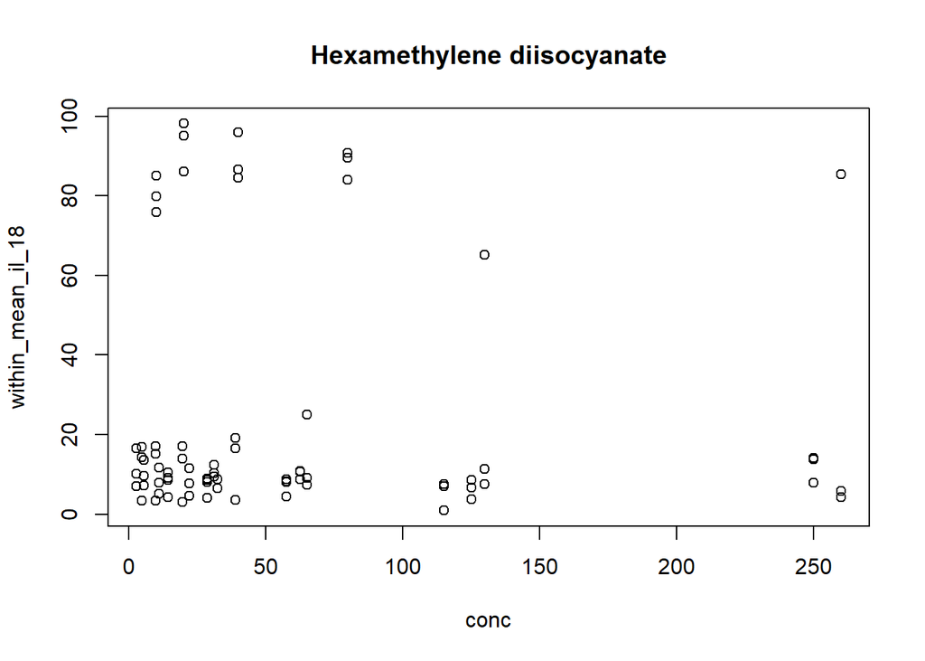

```r
# untransformed
plot(within_mean_il_18 ~ conc, data = teunis_drc %>% filter(chemical == highest_fold[1]), main= highest_fold[1])
```

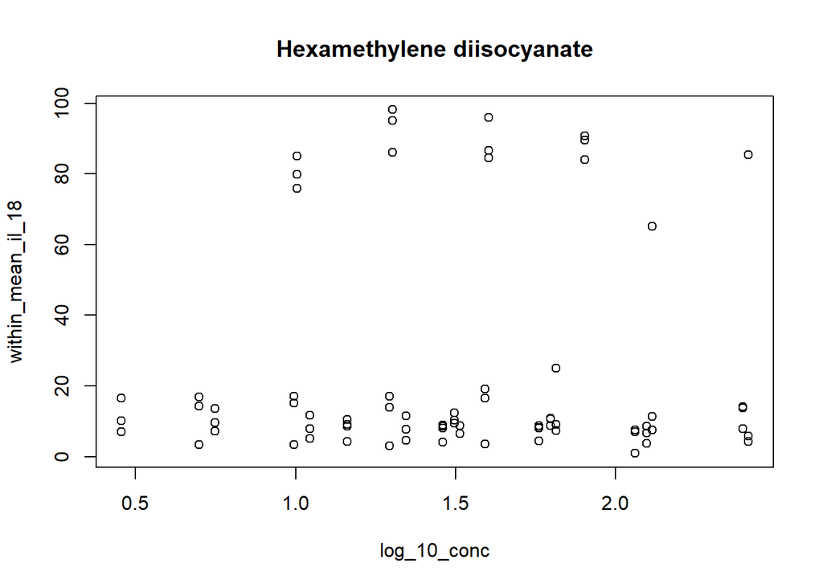

```r
# log10 transformed
plot(within_mean_il_18 ~ log_10_conc, data = teunis_drc %>% filter(chemical == highest_fold[1]), main= highest_fold[1])
```

# Create the drm() model below

```r
m1_1 <- drm(within_mean_viability ~ conc,
             data = teunis_drc %>% filter(chemical == highest_fold[1]),
             fct = LL.4(names = c("Slope", "Lower Limit", "Upper Limit", "ED50")))
# model summary
summary(m1_1)
```

```
##
## Model fitted: Log-logistic (ED50 as parameter) (4 parms)
##
## Parameter estimates:
##
##                          Estimate Std. Error t-value   p-value
## Slope:(Intercept)         0.88041    1.13212  0.7777    0.4393
## Lower Limit:(Intercept)  57.55771   62.58047  0.9197    0.3608
## Upper Limit:(Intercept) 112.91366   12.58822  8.9698 2.377e-13 ***
## ED50:(Intercept)        105.42457  250.34412  0.4211    0.6749
## ---
## Signif. codes:  0 '***' 0.001 '**' 0.01 '*' 0.05 '.' 0.1 ' ' 1
##
## Residual standard error:
##
##  14.78891 (72 degrees of freedom)
```

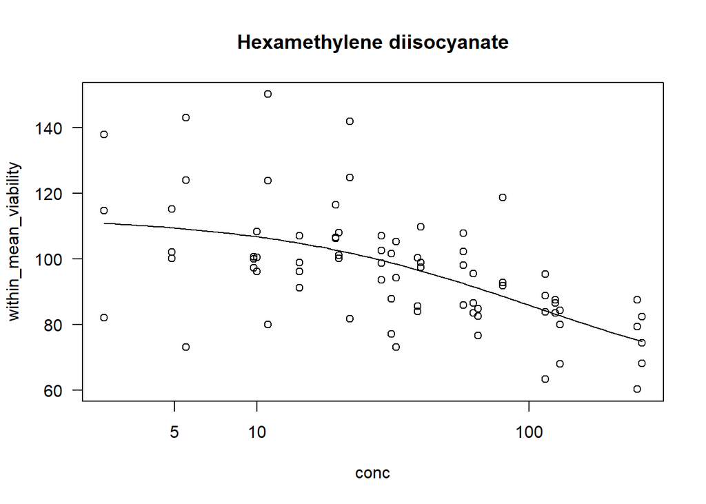

```r
# model plot dose ~ response
plot(m1_1, type = "all", main = highest_fold[1])
```

Compound 2 - Viability

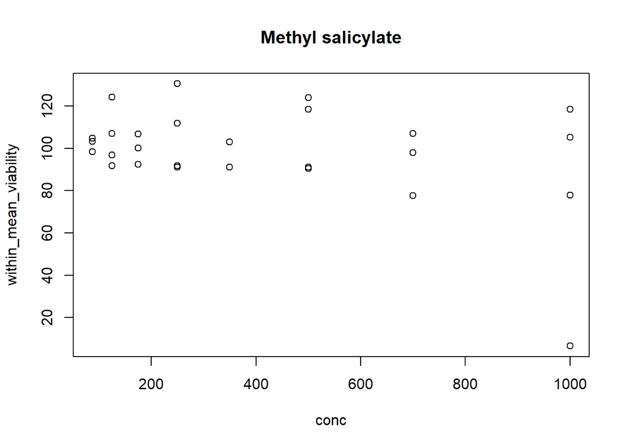

```r
library(drc)

# untransformed
plot(within_mean_viability ~ conc, data = teunis_drc %>% filter(chemical == highest_fold[2]), main= highest_fold[2])
```

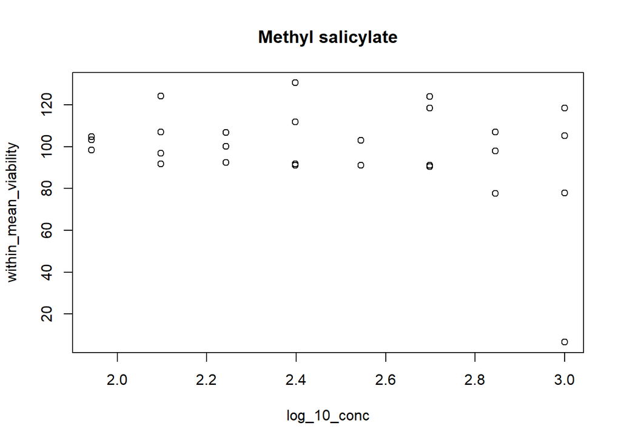

```r
# log10 transformed
plot(within_mean_viability ~ log_10_conc, data = teunis_drc %>% filter(chemical == highest_fold[2]), main= highest_fold[2])
```

```r
# create the drm() model
m1_2 <- drm(within_mean_viability ~ conc,
             data = teunis_drc %>% filter(chemical == highest_fold[2]),
             fct = LL.4(names = c("Slope", "Lower Limit", "Upper Limit", "ED50")))
summary(m1_2)
```

```
##
## Model fitted: Log-logistic (ED50 as parameter) (4 parms)
##
## Parameter estimates:
##
##                          Estimate Std. Error t-value p-value
## Slope:(Intercept)          4.4515     2.0348  2.1877 0.03867 *
## Lower Limit:(Intercept)    4.6905         NA      NA      NA
## Upper Limit:(Intercept)  103.5687     5.1305 20.1869 < 2e-16 ***
## ED50:(Intercept)        1249.3308         NA      NA      NA
## ---
## Signif. codes:  0 '***' 0.001 '**' 0.01 '*' 0.05 '.' 0.1 ' ' 1
##
## Residual standard error:
##
##  21.4136 (24 degrees of freedom)
```

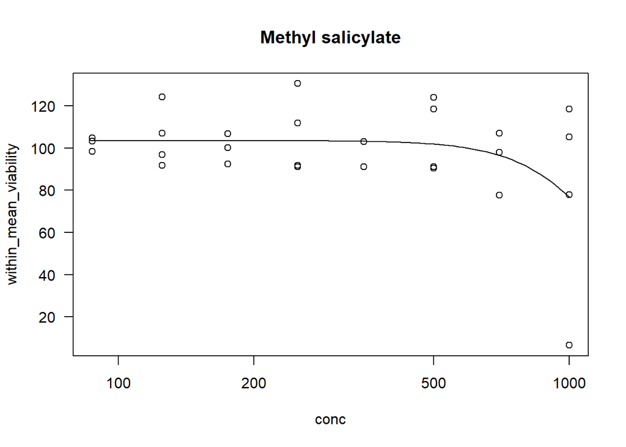

```r
plot(m1_2, type = "all", main = highest_fold[2])
```

## drc to ggplot2 transformation

2G How to convert default plots from drc to ggplot format

To extract information from the `drc::drm()` model that is suitable to plot in ggplot we need to use a special self-written function. This function can be loaded by executing the command below:

```r
source(file.path(root, "code", "plotdrc_to_ggplot2.R"))
```

Below is an example of how to use the function `plotdrc_to_ggpot2()`

```r
## build example model from the NCTC (teunis) data
model = drm(within_mean_viability ~ conc,
             data = teunis_drc %>% filter(chemical == highest_fold[1]),
             fct = LL.4(names = c("Slope", "Lower Limit", "Upper Limit", "ED50")))
xlab = "Concentration"
ylab = "Viability"
ylim = c(30, 150)
xlim = c(0.1, 1000)

max(teunis_drc$conc)
```

```
## [1] 1000
```

```r
min(teunis_drc$conc)
```

```
## [1] 0.1975
```

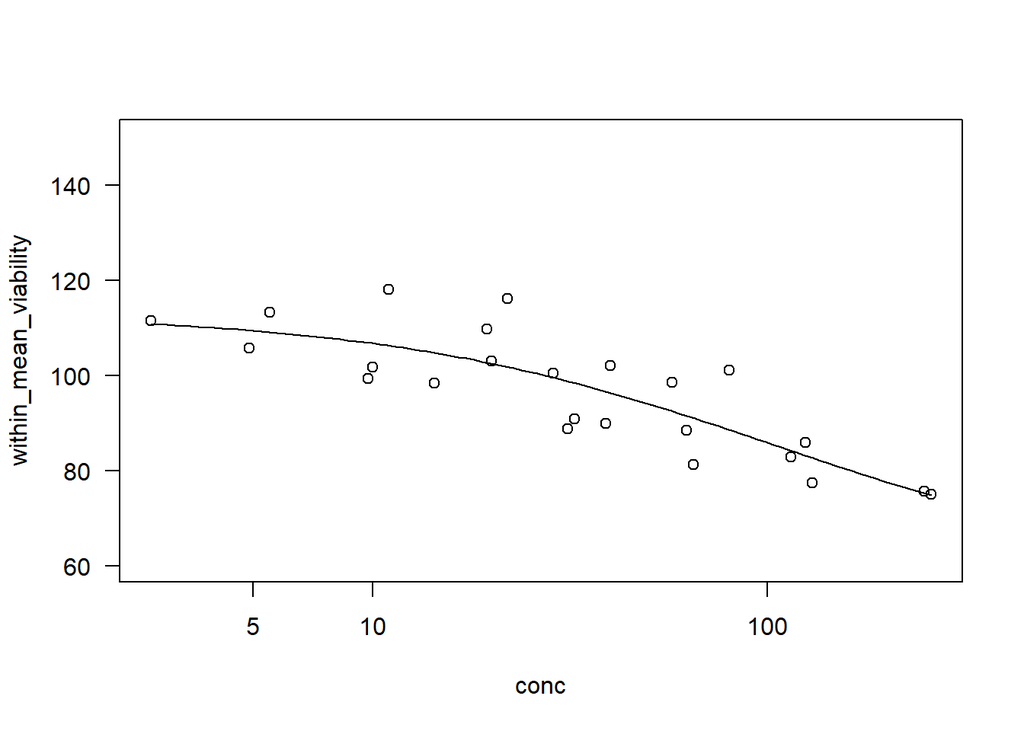

```r
# apply function "plotdrc_to_ggpot2()":

## default drc plot
drc_plot <- plot(model)
```

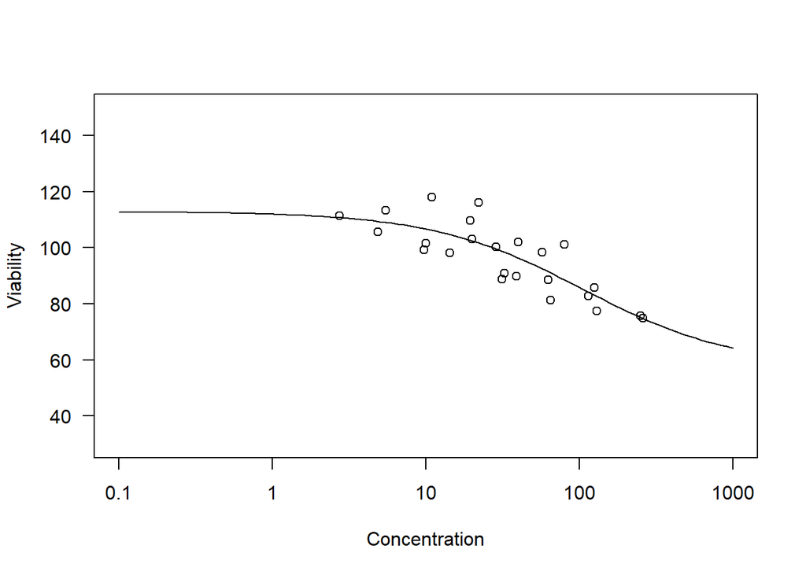

```r
# ggplot2 plot from drc model
ggplot2_plot <- plotdrc_to_ggplot2(x = model,
                                   ylim = ylim,
                                   xlim = xlim,
                                   ylab = ylab,
                                   xlab = xlab)
```

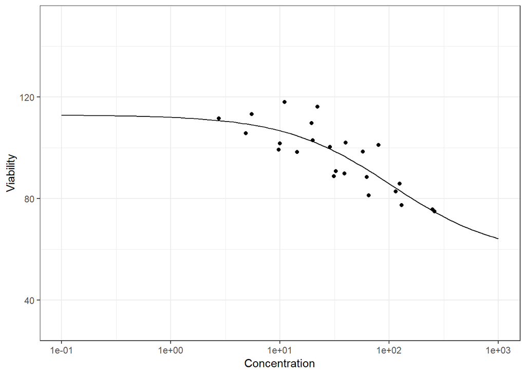

```r
ggplot2_plot
```

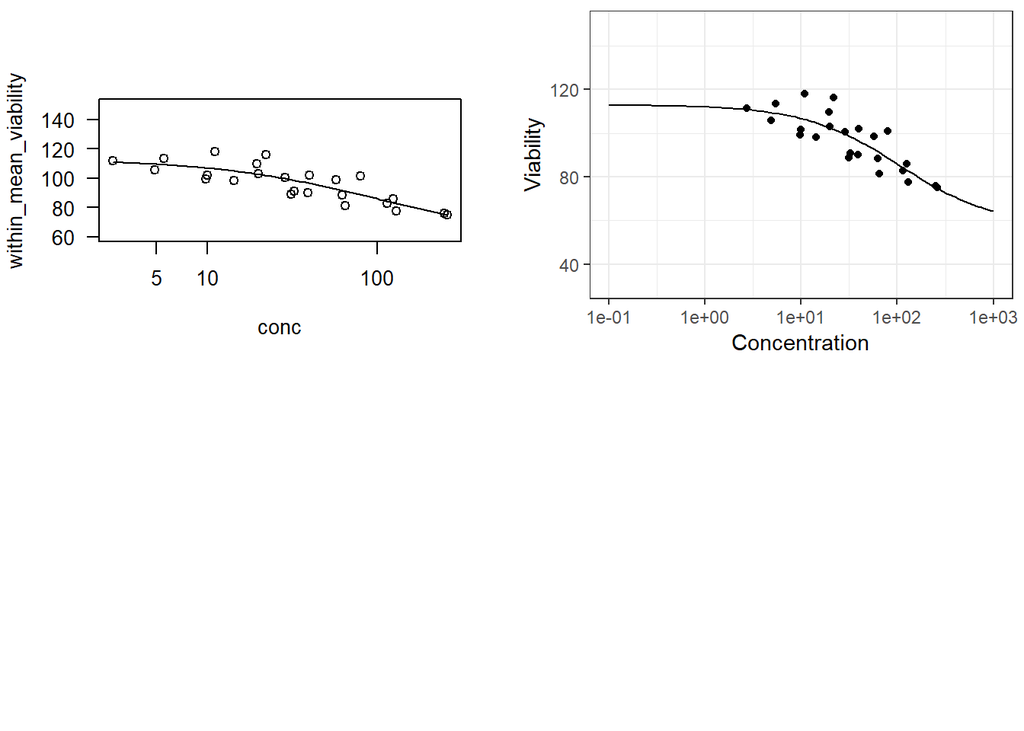

```r
## plots in a panel to compare
library(gridBase)
library(grid)
vp.BottomRight <- viewport(height=unit(0.5, "npc"), width=unit(0.5, "npc"),
                           just=c("left","top"),
                           y=1, x=0.5)


# plot your base graphics
par(mfrow=c(2,2))
plot(model)

# plot the ggplot using the print command
print(ggplot2_plot, vp=vp.BottomRight)
```

2H Create a function (`create_dose_response()`) that models a drc model for each chemical in the `teunis_drc`.

**TIPS**

- Use the following below model for the function
- Create a subset for the data containing the chemical p-Phenylenediamine and test you function on this subset.
- Add the function `ggsave()` to your function. This will save the plot to an image. Use the chemical name in the filename.
- Remember `paste()` and `paste0()`
- Provide a plot title (chemical name)

```
create_dose_response <- function(df, dose, effect){


}
```

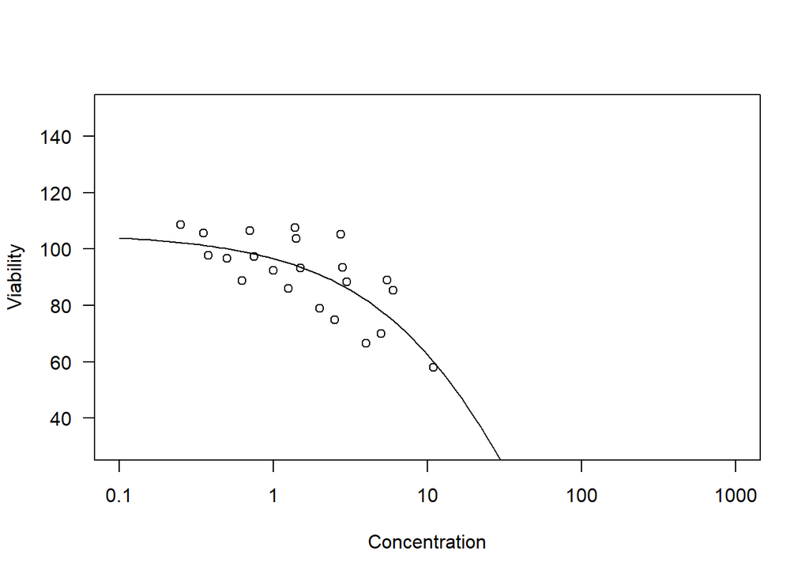

```r
## split teunis_drc by chemical
split_teunis_drc <- split(teunis_drc, teunis_drc$chemical, drop = TRUE)
df  = split_teunis_drc[[12]]

## test arguments
dose = "conc"
effect = "within_mean_viability"
xlim = xlim
ylim = ylim
xlab = xlab
ylab = ylab
path = file.path(root, "images", "drc_plots")


## define function
create_dose_response <- function(df, dose, effect,
                                 xlim, ylim, xlab, ylab, path){

  ## source function to convert base plot to ggplot2
  source(file.path(root, "code", "plotdrc_to_ggplot2.R"))


  ## drc model definition
  model <- drm(unlist(df[,effect]) ~ unlist(df[, dose]),
             data = df,
             fct = LL.4(names = c("Slope", "Lower Limit", "Upper Limit", "ED50")))

  chemical <- df$chemical[1] %>% as.character()


  ## correcting some unhealthy namegiving in the chemicals
  chemical <- stringr::str_replace_all(chemical, pattern = " ", replacement = "_")
  chemical <- stringr::str_replace_all(chemical, pattern = "\\(", replacement = "")
  chemical <- stringr::str_replace_all(chemical, pattern = "\\)", replacement = "")
  chemical <- stringr::str_replace_all(chemical, pattern = "\\%", replacement = "")
  chemical <- stringr::str_replace_all(chemical, pattern = "__", replacement = "_")

  ## where to store the plot
  dir.create(path)
  plot_file_name <- file.path(path, paste0(chemical, ".png"))

  ## define plot title
  plot_title <- chemical

  ## creating the plot in ggplot syntaxis
  gg_plot <- plotdrc_to_ggplot2(x = model,
                                   ylim = ylim,
                                   xlim = xlim,
                                   ylab = ylab,
                                   xlab = xlab,
                                plot_title = plot_title)
  # save plot to dir
  ggsave(filename = plot_file_name)

  # get model summary
  summary_model <- summary(model)

  # put plot and summary in list
  results <- list(gg_plot, summary_model)
  return(results)

  }


## df = teunis_drc %>% filter(chemical == highest_fold[4])
## names(data)



test <- create_dose_response(df = df, dose = "conc", effect = "within_mean_viability",
                     xlim = xlim, ylim = ylim,
                     xlab = xlab, ylab = ylab, path = path)
```

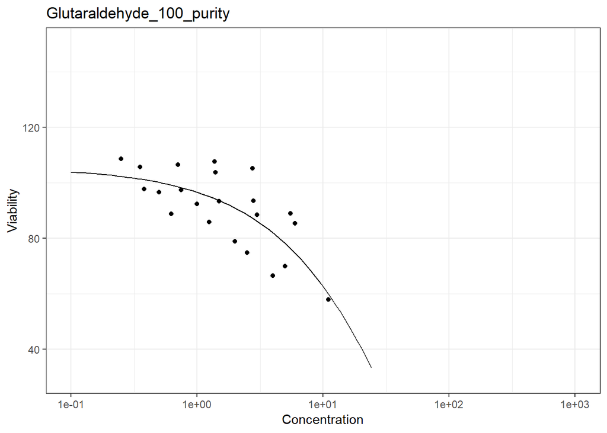

```r
test[[1]]
```

```r
test[[2]]
```

```
##
## Model fitted: Log-logistic (ED50 as parameter) (4 parms)
##
## Parameter estimates:
##
##                           Estimate Std. Error t-value p-value
## Slope:(Intercept)          0.74465    0.43846  1.6983 0.09409 .
## Lower Limit:(Intercept) -160.17476  772.15789 -0.2074 0.83630
## Upper Limit:(Intercept)  105.55897    7.90060 13.3609 < 2e-16 ***
## ED50:(Intercept)          91.09695  498.99320  0.1826 0.85569
## ---
## Signif. codes:  0 '***' 0.001 '**' 0.01 '*' 0.05 '.' 0.1 ' ' 1
##
## Residual standard error:
##
##  13.5003 (67 degrees of freedom)
```

2I Create a ggplot2 plot for each chemical present in the `teunis_drc` dataset, save each image to disk. Use a descriptive name for each file.

**TIPS**

- Use the drc_to_ggplot2, and the `create_dose_response()` function you wrote above
- Split the datset for each chemical using the `split()` command, remember that you need to set `drop = TRUE` in the `split()` call.
- Use the `map()` function from the purrr package or `lapply()` from base R to loop over the split dataset-list

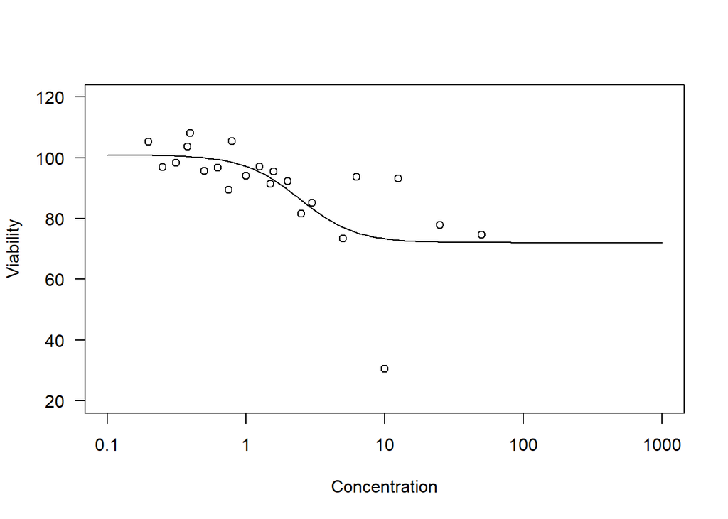

```
## $result
## $result[[1]]
```

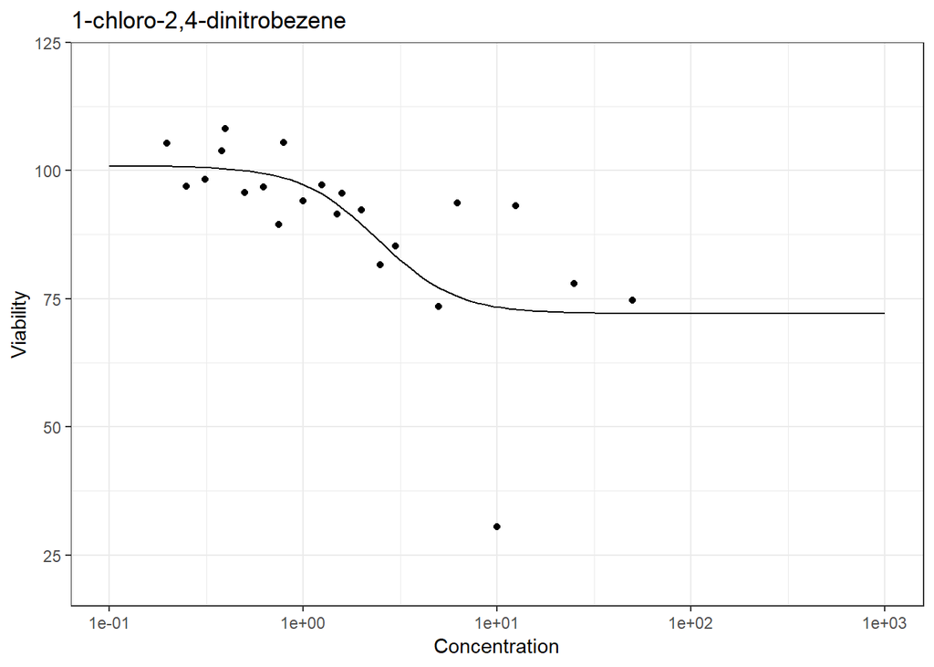

```
##
## $result[[2]]
##
## Model fitted: Log-logistic (ED50 as parameter) (4 parms)
##
## Parameter estimates:
##
##                         Estimate Std. Error t-value p-value
## Slope:(Intercept)         2.1509     1.5688  1.3710 0.17531
## Lower Limit:(Intercept)  72.0855     5.4073 13.3312 < 2e-16 ***
## Upper Limit:(Intercept) 100.9266     4.7616 21.1960 < 2e-16 ***
## ED50:(Intercept)          2.4306     1.0005  2.4293 0.01804 *
## ---
## Signif. codes:  0 '***' 0.001 '**' 0.01 '*' 0.05 '.' 0.1 ' ' 1
##
## Residual standard error:
##
##  17.31246 (62 degrees of freedom)
##
##
## $error
## NULL
```

```r
## creating a safe version of create_dose_response() with purrr::safely
safe_create_dose_response <- purrr::safely(create_dose_response)

## test function on first element
safe_create_dose_response(split_teunis_drc[[1]],
          dose = "conc", effect = "within_mean_viability",
                     xlim = c(0.1, 1000) , ylim = c(20, 120),
                     xlab = xlab, ylab = ylab, path = path)
```

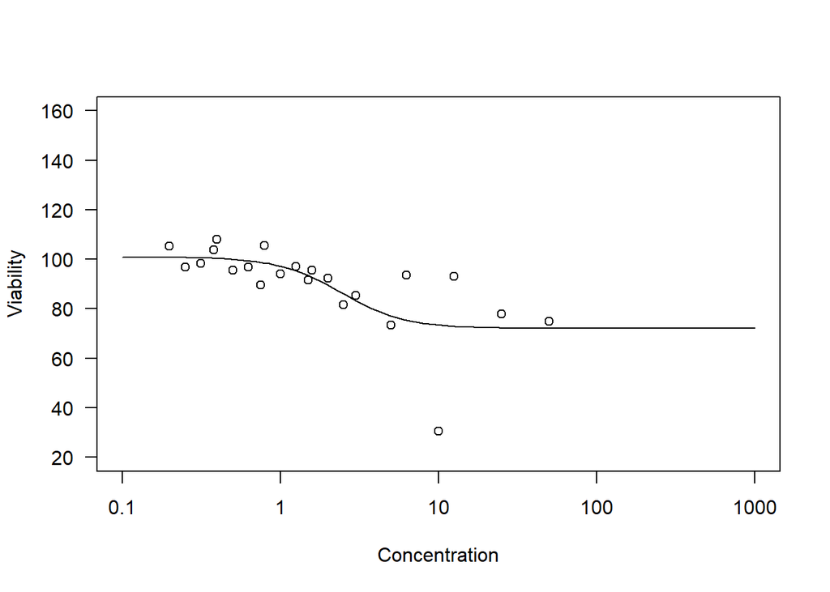

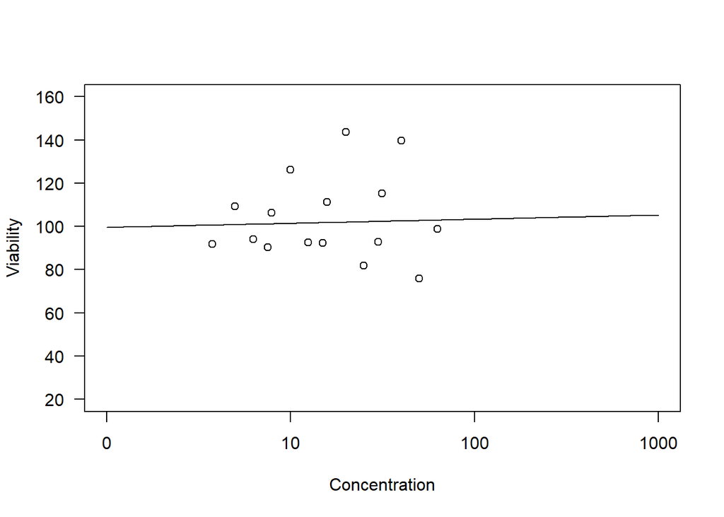

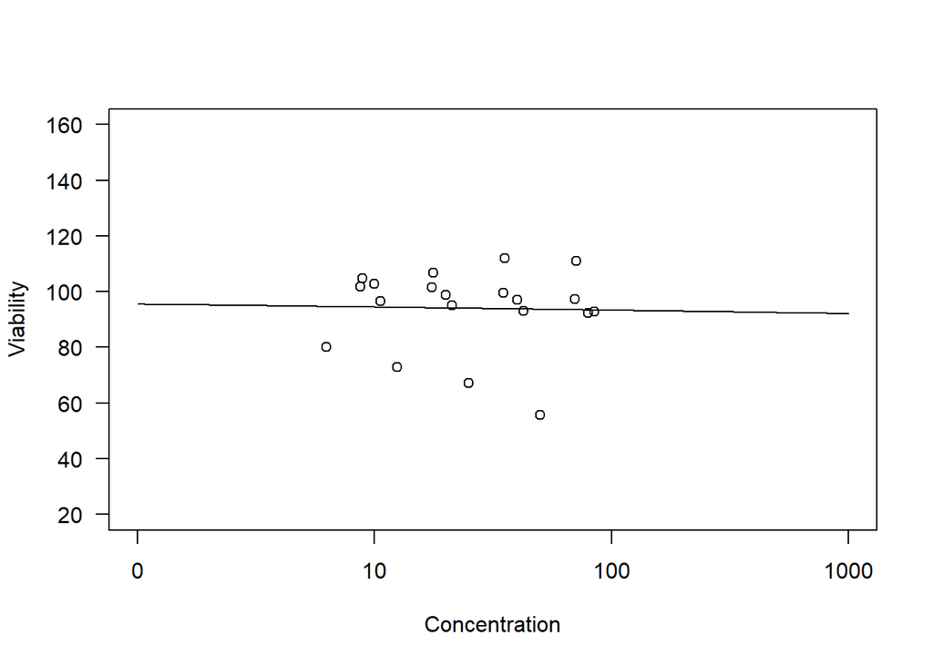

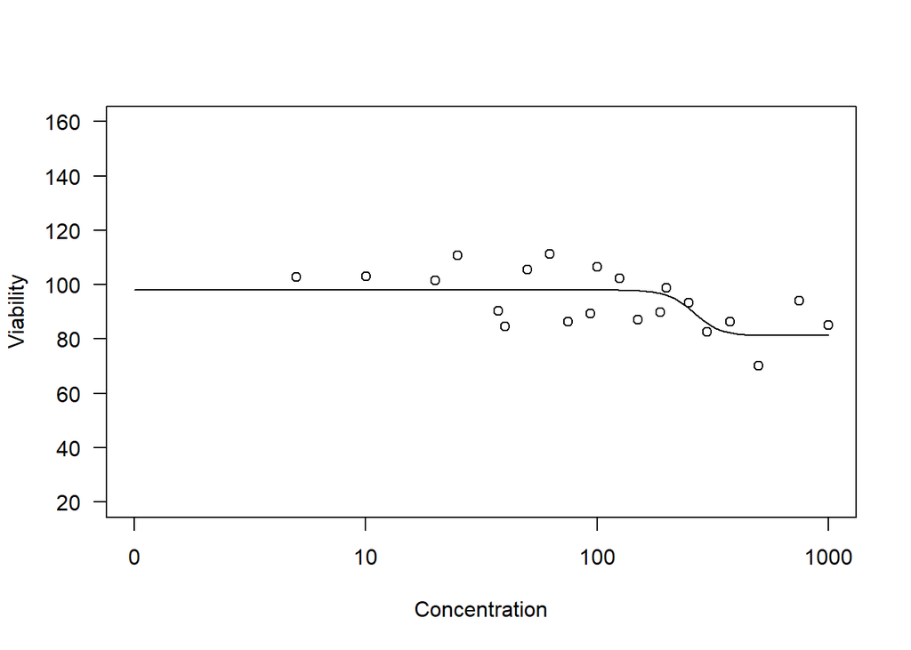

```
## Error in optim(startVec, opfct, hessian = TRUE, method = optMethod, control = list(maxit = maxIt,  :
##   non-finite finite-difference value [4]
```

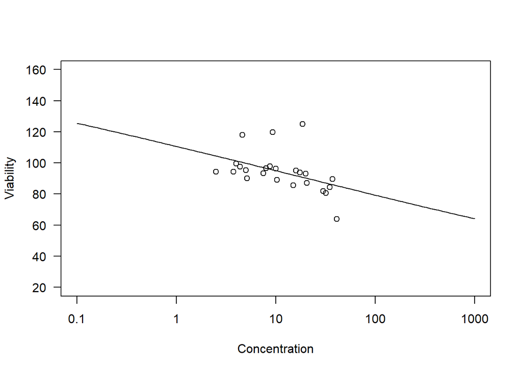

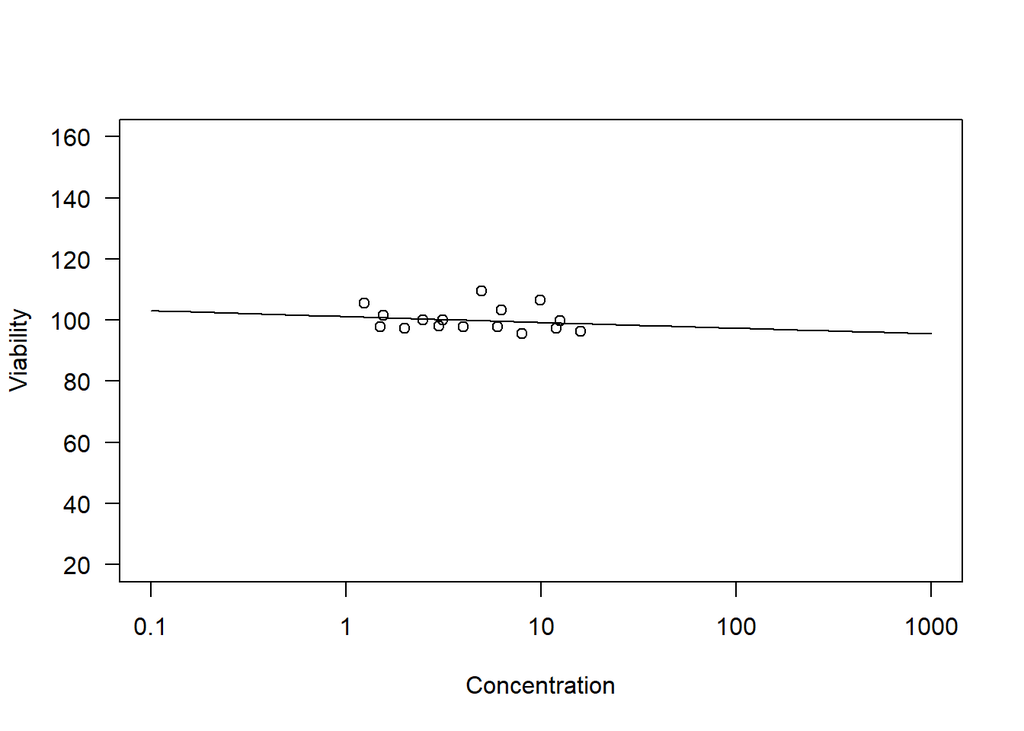

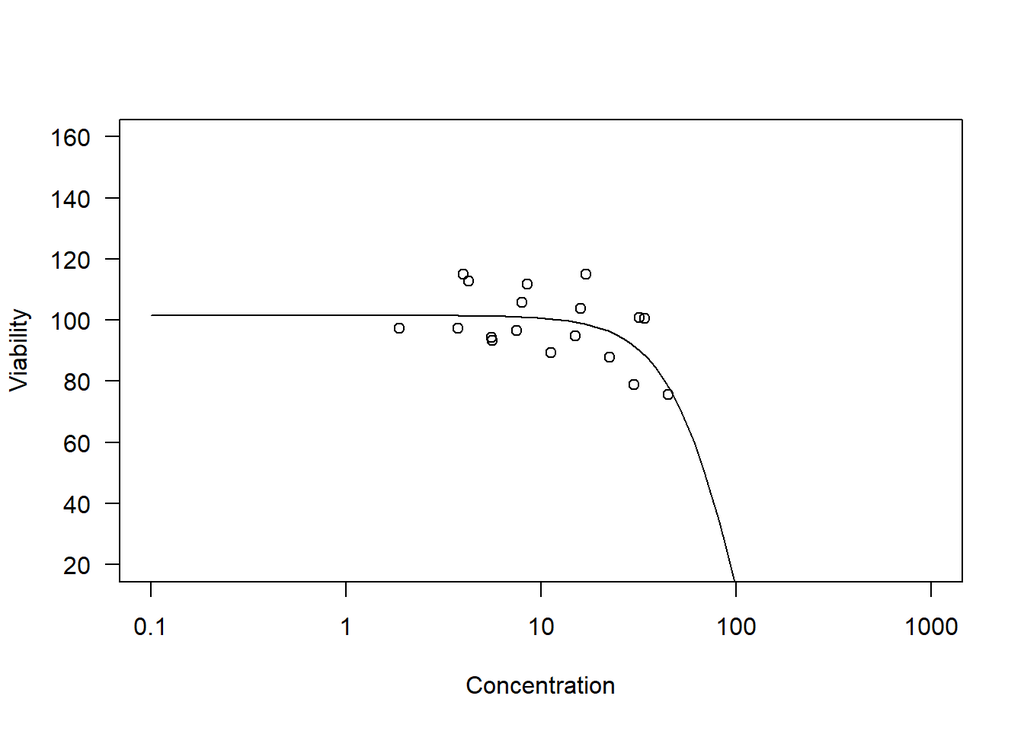

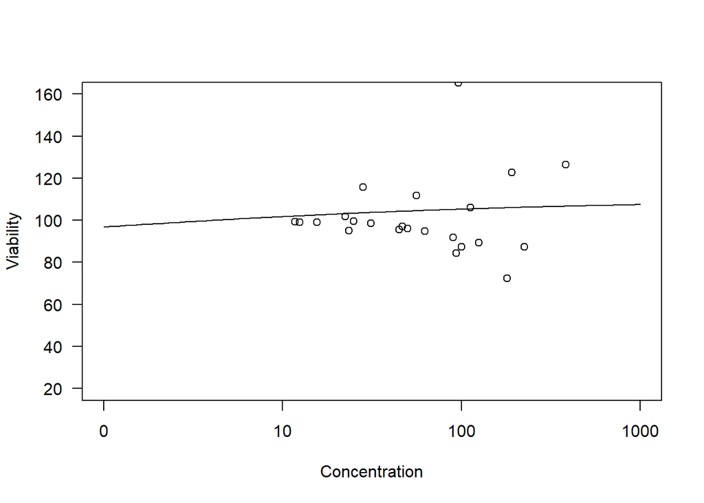

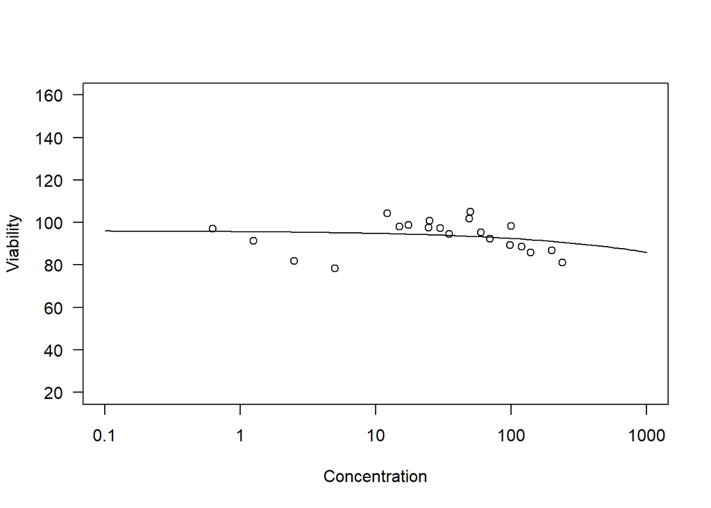

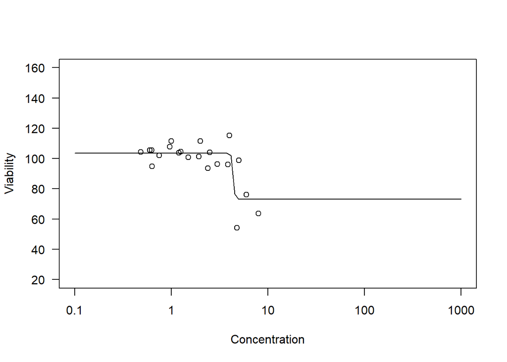

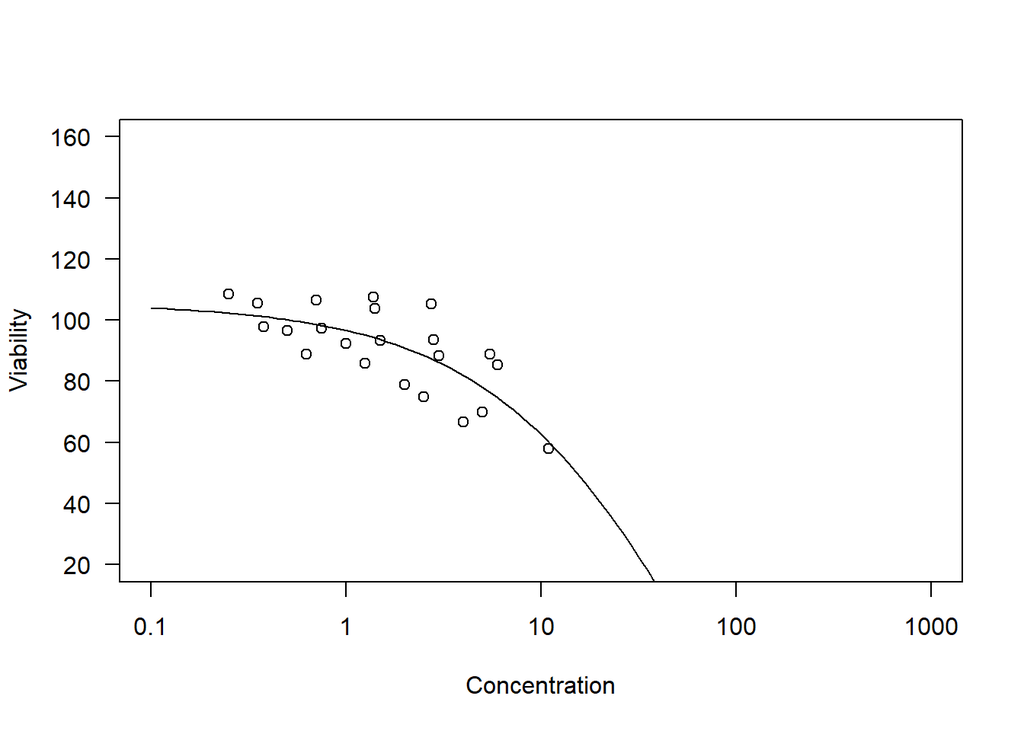

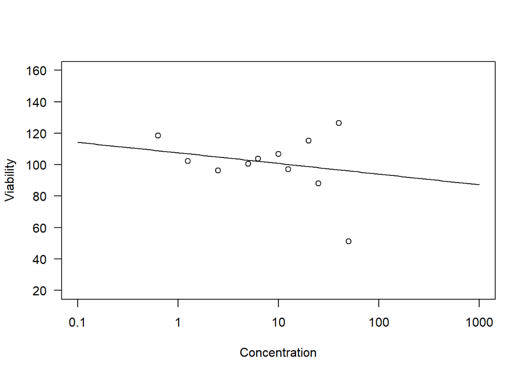

[15 more figures not shown]

```r
## apply function to split
plot_list <- lapply(split_teunis_drc, safe_create_dose_response,
          dose = "conc", effect = "within_mean_viability",
                     xlim = c(0.1, 1000) , ylim = c(20, 160),
                     xlab = xlab, ylab = ylab, path = path)
```

```r
## check for errors
plot_list_transposed <- purrr::transpose(plot_list)
plot_list_transposed[[1]]
```

```
## $`1-chloro-2,4-dinitrobezene`
## $`1-chloro-2,4-dinitrobezene`[[1]]
```

```
##
## $`1-chloro-2,4-dinitrobezene`[[2]]
##
## Model fitted: Log-logistic (ED50 as parameter) (4 parms)
##
## Parameter estimates:
##
##                         Estimate Std. Error t-value p-value
## Slope:(Intercept)         2.1509     1.5688  1.3710 0.17531
## Lower Limit:(Intercept)  72.0855     5.4073 13.3312 < 2e-16 ***
## Upper Limit:(Intercept) 100.9266     4.7616 21.1960 < 2e-16 ***
## ED50:(Intercept)          2.4306     1.0005  2.4293 0.01804 *
## ---
## Signif. codes:  0 '***' 0.001 '**' 0.01 '*' 0.05 '.' 0.1 ' ' 1
##
## Residual standard error:
##
##  17.31246 (62 degrees of freedom)
##
##
## $`2-Mercaptobenzothiazol`
## $`2-Mercaptobenzothiazol`[[1]]
```

```
##
## $`2-Mercaptobenzothiazol`[[2]]
##
## Model fitted: Log-logistic (ED50 as parameter) (4 parms)
##
## Parameter estimates:
##
##                           Estimate Std. Error t-value p-value
## Slope:(Intercept)        -0.063782   0.938908 -0.0679  0.9461
## Lower Limit:(Intercept)  78.985989 417.063632  0.1894  0.8505
## Upper Limit:(Intercept) 131.388525 350.543806  0.3748  0.7093
## ED50:(Intercept)        976.539738         NA      NA      NA
##
## Residual standard error:
##
##  29.43056 (52 degrees of freedom)
##
##
## $`Ammonium persulphate`
## $`Ammonium persulphate`[[1]]
```

```
##
## $`Ammonium persulphate`[[2]]
##
## Model fitted: Log-logistic (ED50 as parameter) (4 parms)
##
## Parameter estimates:
##
##                           Estimate Std. Error t-value p-value
## Slope:(Intercept)       9.4034e-02 5.6631e+00  0.0166  0.9868
## Lower Limit:(Intercept) 7.7094e+01 4.4932e+02  0.1716  0.8643
## Upper Limit:(Intercept) 1.0154e+02 5.6194e+02  0.1807  0.8572
## ED50:(Intercept)        1.3660e+05 1.2573e+07  0.0109  0.9914
##
## Residual standard error:
##
##  14.963 (64 degrees of freedom)
##
##
## $Benzocaine
## $Benzocaine[[1]]
```

```
##
## $Benzocaine[[2]]
##
## Model fitted: Log-logistic (ED50 as parameter) (4 parms)
##
## Parameter estimates:
##
##                         Estimate Std. Error t-value   p-value
## Slope:(Intercept)         7.5547    28.0031  0.2698 0.7880686
## Lower Limit:(Intercept)  81.2374     3.1676 25.6460 < 2.2e-16 ***
## Upper Limit:(Intercept)  97.9899     3.3273 29.4503 < 2.2e-16 ***
## ED50:(Intercept)        263.0478    75.6070  3.4791 0.0008413 ***
## ---
## Signif. codes:  0 '***' 0.001 '**' 0.01 '*' 0.05 '.' 0.1 ' ' 1
##
## Residual standard error:
##
##  12.50729 (75 degrees of freedom)
##
##
## $Chlorobenzene
## NULL
##
## $Cinnamaldehyde
## $Cinnamaldehyde[[1]]
```

```
##
## $Cinnamaldehyde[[2]]
##
## Model fitted: Log-logistic (ED50 as parameter) (4 parms)
##
## Parameter estimates:
##
##                          Estimate Std. Error t-value p-value
## Slope:(Intercept)         0.12763         NA      NA      NA
## Lower Limit:(Intercept) -15.06620         NA      NA      NA
## Upper Limit:(Intercept) 200.00203         NA      NA      NA
## ED50:(Intercept)         14.53321   42.58613  0.3413  0.7338
##
## Residual standard error:
##
##  14.57345 (76 degrees of freedom)
##
##
## $Citral
## $Citral[[1]]
```

```
##
## $Citral[[2]]
##
## Model fitted: Log-logistic (ED50 as parameter) (4 parms)
##
## Parameter estimates:
##
##                           Estimate Std. Error t-value p-value
## Slope:(Intercept)         0.072040         NA      NA      NA
## Lower Limit:(Intercept)  79.566727         NA      NA      NA
## Upper Limit:(Intercept) 126.721317         NA      NA      NA
## ED50:(Intercept)          0.090744   2.599510  0.0349  0.9723
##
## Residual standard error:
##
##  6.33099 (56 degrees of freedom)
##
##
## $`Cobalt (II) chloride`
## $`Cobalt (II) chloride`[[1]]
```

```
##
## $`Cobalt (II) chloride`[[2]]
##
## Model fitted: Log-logistic (ED50 as parameter) (4 parms)
##
## Parameter estimates:
##
##                          Estimate Std. Error t-value p-value
## Slope:(Intercept)          2.2822     1.6306  1.3996  0.1670
## Lower Limit:(Intercept)  -91.2879  1336.4474 -0.0683  0.9458
## Upper Limit:(Intercept)  101.5271     2.8629 35.4633  <2e-16 ***
## ED50:(Intercept)         107.1506   395.2223  0.2711  0.7873
## ---
## Signif. codes:  0 '***' 0.001 '**' 0.01 '*' 0.05 '.' 0.1 ' ' 1
##
## Residual standard error:
##
##  14.25259 (58 degrees of freedom)
##
##
## $`Ethyl vanillin`
## $`Ethyl vanillin`[[1]]
```

```
##
## $`Ethyl vanillin`[[2]]
##
## Model fitted: Log-logistic (ED50 as parameter) (4 parms)
##
## Parameter estimates:
##
##                          Estimate Std. Error t-value p-value
## Slope:(Intercept)         0.31080         NA      NA      NA
## Lower Limit:(Intercept) 109.83212         NA      NA      NA
## Upper Limit:(Intercept)  77.89902         NA      NA      NA
## ED50:(Intercept)          0.30454         NA      NA      NA
##
## Residual standard error:
##
##  32.01334 (68 degrees of freedom)
##
##
## $Euganol
## $Euganol[[1]]
```

```
##
## $Euganol[[2]]
##
## Model fitted: Log-logistic (ED50 as parameter) (4 parms)
##
## Parameter estimates:
##
##                            Estimate  Std. Error t-value p-value
## Slope:(Intercept)        4.5684e-01  3.4645e-01  1.3186  0.1921
## Lower Limit:(Intercept) -2.5055e+02  1.3911e+03 -0.1801  0.8576
## Upper Limit:(Intercept)  9.6097e+01  3.2065e+00 29.9699  <2e-16 ***
## ED50:(Intercept)         2.1348e+06  1.5776e+06  1.3531  0.1808
## ---
## Signif. codes:  0 '***' 0.001 '**' 0.01 '*' 0.05 '.' 0.1 ' ' 1
##
## Residual standard error:
##
##  12.05332 (63 degrees of freedom)
##
##
## $Formaldehyde
## $Formaldehyde[[1]]
```

```
##
## $Formaldehyde[[2]]
##
## Model fitted: Log-logistic (ED50 as parameter) (4 parms)
##
## Parameter estimates:
##
##                         Estimate Std. Error t-value p-value
## Slope:(Intercept)        53.8282    31.5344   1.707 0.09309 .
## Lower Limit:(Intercept)  73.0898     3.2270  22.649 < 2e-16 ***
## Upper Limit:(Intercept) 103.4460     1.5633  66.171 < 2e-16 ***
## ED50:(Intercept)          4.3646     0.2156  20.244 < 2e-16 ***
## ---
## Signif. codes:  0 '***' 0.001 '**' 0.01 '*' 0.05 '.' 0.1 ' ' 1
##
## Residual standard error:
##
##  11.15043 (59 degrees of freedom)
##
##
## $`Glutaraldehyde (100% purity)`
## $`Glutaraldehyde (100% purity)`[[1]]
```

```
##
## $`Glutaraldehyde (100% purity)`[[2]]
##
## Model fitted: Log-logistic (ED50 as parameter) (4 parms)
##
## Parameter estimates:
##
##                           Estimate Std. Error t-value p-value
## Slope:(Intercept)          0.74465    0.43846  1.6983 0.09409 .
## Lower Limit:(Intercept) -160.17476  772.15789 -0.2074 0.83630
## Upper Limit:(Intercept)  105.55897    7.90060 13.3609 < 2e-16 ***
## ED50:(Intercept)          91.09695  498.99320  0.1826 0.85569
## ---
## Signif. codes:  0 '***' 0.001 '**' 0.01 '*' 0.05 '.' 0.1 ' ' 1
##
## Residual standard error:
##
##  13.5003 (67 degrees of freedom)
##
##
## $Hexachloroplatinate
## $Hexachloroplatinate[[1]]
```

```
##
## $Hexachloroplatinate[[2]]
##
## Model fitted: Log-logistic (ED50 as parameter) (4 parms)
##
## Parameter estimates:
##
##                           Estimate Std. Error t-value p-value
## Slope:(Intercept)       7.9778e-02 2.1652e+00  0.0368  0.9708
## Lower Limit:(Intercept) 2.3911e+01 1.7972e+03  0.0133  0.9894
## Upper Limit:(Intercept) 1.7234e+02 2.1578e+03  0.0799  0.9367
## ED50:(Intercept)        2.4786e+01 1.8281e+03  0.0136  0.9892
##
## Residual standard error:
##
##  24.52984 (41 degrees of freedom)
##
##
## $`Hexamethylene diisocyanate`
## $`Hexamethylene diisocyanate`[[1]]
```

```
##
## $`Hexamethylene diisocyanate`[[2]]
##
## Model fitted: Log-logistic (ED50 as parameter) (4 parms)
##
## Parameter estimates:
##
##                          Estimate Std. Error t-value   p-value
## Slope:(Intercept)         0.88041    1.13212  0.7777    0.4393
## Lower Limit:(Intercept)  57.55771   62.58047  0.9197    0.3608
## Upper Limit:(Intercept) 112.91366   12.58822  8.9698 2.377e-13 ***
## ED50:(Intercept)        105.42457  250.34412  0.4211    0.6749
## ---
## Signif. codes:  0 '***' 0.001 '**' 0.01 '*' 0.05 '.' 0.1 ' ' 1
##
## Residual standard error:
##
##  14.78891 (72 degrees of freedom)
##
##
## $Isoeuganol
## $Isoeuganol[[1]]
```

```
##
## $Isoeuganol[[2]]
##
## Model fitted: Log-logistic (ED50 as parameter) (4 parms)
##
## Parameter estimates:
##
##                         Estimate Std. Error t-value p-value
## Slope:(Intercept)         2.7069     7.7433  0.3496  0.7276
## Lower Limit:(Intercept)  80.2739    54.9758  1.4602  0.1484
## Upper Limit:(Intercept) 108.5956     6.4841 16.7481  <2e-16 ***
## ED50:(Intercept)         86.7052   138.1426  0.6277  0.5321
## ---
## Signif. codes:  0 '***' 0.001 '**' 0.01 '*' 0.05 '.' 0.1 ' ' 1
##
## Residual standard error:
##
##  17.29403 (76 degrees of freedom)
##
##
## $`Methyl salicylate`
## $`Methyl salicylate`[[1]]
```

```
##
## $`Methyl salicylate`[[2]]
##
## Model fitted: Log-logistic (ED50 as parameter) (4 parms)
##
## Parameter estimates:
##
##                          Estimate Std. Error t-value p-value
## Slope:(Intercept)          4.4515     2.0348  2.1877 0.03867 *
## Lower Limit:(Intercept)    4.6905         NA      NA      NA
## Upper Limit:(Intercept)  103.5687     5.1305 20.1869 < 2e-16 ***
## ED50:(Intercept)        1249.3308         NA      NA      NA
## ---
## Signif. codes:  0 '***' 0.001 '**' 0.01 '*' 0.05 '.' 0.1 ' ' 1
##
## Residual standard error:
##
##  21.4136 (24 degrees of freedom)
##
##
## $`Octanoic acid`
## $`Octanoic acid`[[1]]
```

```
##
## $`Octanoic acid`[[2]]
##
## Model fitted: Log-logistic (ED50 as parameter) (4 parms)
##
## Parameter estimates:
##
##                         Estimate Std. Error t-value   p-value
## Slope:(Intercept)         1.7114     2.1573  0.7933    0.4303
## Lower Limit:(Intercept)  82.3319    12.6131  6.5275 9.963e-09 ***
## Upper Limit:(Intercept) 101.7004     5.4928 18.5151 < 2.2e-16 ***
## ED50:(Intercept)        128.5211   108.1814  1.1880    0.2390
## ---
## Signif. codes:  0 '***' 0.001 '**' 0.01 '*' 0.05 '.' 0.1 ' ' 1
##
## Residual standard error:
##
##  11.31204 (68 degrees of freedom)
##
##
## $Oxazolone
## $Oxazolone[[1]]
```

```
##
## $Oxazolone[[2]]
##
## Model fitted: Log-logistic (ED50 as parameter) (4 parms)
##
## Parameter estimates:
##
##                         Estimate Std. Error t-value   p-value
## Slope:(Intercept)         8.7774     5.2602  1.6686    0.1002
## Lower Limit:(Intercept)  80.7732     3.3623 24.0233 < 2.2e-16 ***
## Upper Limit:(Intercept)  99.8932     1.5627 63.9226 < 2.2e-16 ***
## ED50:(Intercept)        121.9297    20.2096  6.0333 9.318e-08 ***
## ---
## Signif. codes:  0 '***' 0.001 '**' 0.01 '*' 0.05 '.' 0.1 ' ' 1
##
## Residual standard error:
##
##  10.40534 (63 degrees of freedom)
##
##
## $`p-Phenylenediamine`
## $`p-Phenylenediamine`[[1]]
```

```
##
## $`p-Phenylenediamine`[[2]]
##
## Model fitted: Log-logistic (ED50 as parameter) (4 parms)
##
## Parameter estimates:
##
##                         Estimate Std. Error t-value   p-value
## Slope:(Intercept)         2.7905     2.4116  1.1571   0.25110
## Lower Limit:(Intercept)  76.9752     8.4239  9.1377 1.308e-13 ***
## Upper Limit:(Intercept) 109.2870     6.0428 18.0855 < 2.2e-16 ***
## ED50:(Intercept)         61.0579    18.3994  3.3185   0.00143 **
## ---
## Signif. codes:  0 '***' 0.001 '**' 0.01 '*' 0.05 '.' 0.1 ' ' 1
##
## Residual standard error:
##
##  16.45564 (71 degrees of freedom)
##
##
## $Phenol
## $Phenol[[1]]
```

```
##
## $Phenol[[2]]
##
## Model fitted: Log-logistic (ED50 as parameter) (4 parms)
##
## Parameter estimates:
##
##                            Estimate  Std. Error t-value p-value
## Slope:(Intercept)          0.080386    0.578751  0.1389  0.8898
## Lower Limit:(Intercept)  -25.316638  868.559713 -0.0291  0.9768
## Upper Limit:(Intercept)  234.440020 1008.222314  0.2325  0.8167
## ED50:(Intercept)          38.010625  700.779894  0.0542  0.9569
##
## Residual standard error:
##
##  14.71456 (88 degrees of freedom)
##
##
## $Phenylacetonealdehyde
## $Phenylacetonealdehyde[[1]]
```

```
##
## $Phenylacetonealdehyde[[2]]
##
## Model fitted: Log-logistic (ED50 as parameter) (4 parms)
##
## Parameter estimates:
##
##                           Estimate Std. Error t-value p-value
## Slope:(Intercept)         0.107763   3.859548  0.0279  0.9778
## Lower Limit:(Intercept)  79.732075 725.703131  0.1099  0.9129
## Upper Limit:(Intercept) 125.576046 695.211982  0.1806  0.8573
## ED50:(Intercept)          0.088704   1.330767  0.0667  0.9471
##
## Residual standard error:
##
##  18.47703 (56 degrees of freedom)
##
##
## $`Propylene glycol`
## $`Propylene glycol`[[1]]
```

```
##
## $`Propylene glycol`[[2]]
##
## Model fitted: Log-logistic (ED50 as parameter) (4 parms)
##
## Parameter estimates:
##
##                          Estimate Std. Error t-value   p-value
## Slope:(Intercept)          0.6065     2.0078  0.3021 0.7649983
## Lower Limit:(Intercept)   80.6632    54.0493  1.4924 0.1476300
## Upper Limit:(Intercept)  103.8947    24.2381  4.2864 0.0002208 ***
## ED50:(Intercept)        1128.4684  7177.6672  0.1572 0.8762865
## ---
## Signif. codes:  0 '***' 0.001 '**' 0.01 '*' 0.05 '.' 0.1 ' ' 1
##
## Residual standard error:
##
##  6.090087 (26 degrees of freedom)
##
##
## $`Salicytic acid`
## $`Salicytic acid`[[1]]
```

```
##
## $`Salicytic acid`[[2]]
##
## Model fitted: Log-logistic (ED50 as parameter) (4 parms)
##
## Parameter estimates:
##
##                         Estimate Std. Error t-value   p-value
## Slope:(Intercept)         3.9588     4.6021  0.8602  0.394037
## Lower Limit:(Intercept)  91.0621     4.3445 20.9605 < 2.2e-16 ***
## Upper Limit:(Intercept) 106.3489     2.6952 39.4590 < 2.2e-16 ***
## ED50:(Intercept)        245.3332    84.6488  2.8982  0.005685 **
## ---
## Signif. codes:  0 '***' 0.001 '**' 0.01 '*' 0.05 '.' 0.1 ' ' 1
##
## Residual standard error:
##
##  13.24587 (47 degrees of freedom)
##
##
## $`Sodium lauryl sulphate`
## $`Sodium lauryl sulphate`[[1]]
```

```
##
## $`Sodium lauryl sulphate`[[2]]
##
## Model fitted: Log-logistic (ED50 as parameter) (4 parms)
##
## Parameter estimates:
##
##                          Estimate Std. Error t-value p-value
## Slope:(Intercept)          7.1995     8.2984  0.8676  0.3889
## Lower Limit:(Intercept) -356.1904  3561.0260 -0.1000  0.9206
## Upper Limit:(Intercept)   98.7649     2.3922 41.2867  <2e-16 ***
## ED50:(Intercept)          95.9572   118.9889  0.8064  0.4230
## ---
## Signif. codes:  0 '***' 0.001 '**' 0.01 '*' 0.05 '.' 0.1 ' ' 1
##
## Residual standard error:
##
##  16.64996 (64 degrees of freedom)
##
##
## $`Toluene disicyanate`
## $`Toluene disicyanate`[[1]]
```

```
##
## $`Toluene disicyanate`[[2]]
##
## Model fitted: Log-logistic (ED50 as parameter) (4 parms)
##
## Parameter estimates:
##
##                           Estimate Std. Error t-value p-value
## Slope:(Intercept)         0.063464   0.394527  0.1609  0.8728
## Lower Limit:(Intercept)  38.807988 279.019190  0.1391  0.8899
## Upper Limit:(Intercept) 134.808239 319.809763  0.4215  0.6751
## ED50:(Intercept)         13.967324         NA      NA      NA
##
## Residual standard error:
##
##  15.5563 (51 degrees of freedom)
##
##
## $`Trimellitic anhydride`
## NULL
##
## $`Tween 80`
## $`Tween 80`[[1]]
```

```
##
## $`Tween 80`[[2]]
##
## Model fitted: Log-logistic (ED50 as parameter) (4 parms)
##
## Parameter estimates:
##
##                          Estimate Std. Error t-value p-value
## Slope:(Intercept)         1.08304    0.63109  1.7161 0.09147 .
## Lower Limit:(Intercept)  72.80103    5.52964 13.1656 < 2e-16 ***
## Upper Limit:(Intercept) 101.08117    6.11116 16.5404 < 2e-16 ***
## ED50:(Intercept)         64.56996   39.01020  1.6552 0.10328
## ---
## Signif. codes:  0 '***' 0.001 '**' 0.01 '*' 0.05 '.' 0.1 ' ' 1
##
## Residual standard error:
##
##  10.19757 (58 degrees of freedom)
##
##
## $`x-Hexylcinnamaldehyde`
## $`x-Hexylcinnamaldehyde`[[1]]
```

```
##
## $`x-Hexylcinnamaldehyde`[[2]]
##
## Model fitted: Log-logistic (ED50 as parameter) (4 parms)
##
## Parameter estimates:
##
##                          Estimate Std. Error t-value p-value
## Slope:(Intercept)         0.13219         NA      NA      NA
## Lower Limit:(Intercept)  57.26630         NA      NA      NA
## Upper Limit:(Intercept) 141.18656         NA      NA      NA
## ED50:(Intercept)         13.41410         NA      NA      NA
##
## Residual standard error:
##
##  9.758693 (59 degrees of freedom)
##
##
## $`Zinc sulphate`
## $`Zinc sulphate`[[1]]
```

```
##
## $`Zinc sulphate`[[2]]
##
## Model fitted: Log-logistic (ED50 as parameter) (4 parms)
##
## Parameter estimates:
##
##                          Estimate Std. Error t-value   p-value
## Slope:(Intercept)         12.6585     5.9120  2.1412   0.03565 *
## Lower Limit:(Intercept) -132.1111   422.3546 -0.3128   0.75534
## Upper Limit:(Intercept)   98.0590     1.7051 57.5077 < 2.2e-16 ***
## ED50:(Intercept)         368.9021    81.7852  4.5106 2.457e-05 ***
## ---
## Signif. codes:  0 '***' 0.001 '**' 0.01 '*' 0.05 '.' 0.1 ' ' 1
##
## Residual standard error:
##
##  13.94545 (72 degrees of freedom)
```

```r
plot_list_transposed$result
```

```
## $`1-chloro-2,4-dinitrobezene`
## $`1-chloro-2,4-dinitrobezene`[[1]]
```

```
##
## $`1-chloro-2,4-dinitrobezene`[[2]]
##
## Model fitted: Log-logistic (ED50 as parameter) (4 parms)
##
## Parameter estimates:
##
##                         Estimate Std. Error t-value p-value
## Slope:(Intercept)         2.1509     1.5688  1.3710 0.17531
## Lower Limit:(Intercept)  72.0855     5.4073 13.3312 < 2e-16 ***
## Upper Limit:(Intercept) 100.9266     4.7616 21.1960 < 2e-16 ***
## ED50:(Intercept)          2.4306     1.0005  2.4293 0.01804 *
## ---
## Signif. codes:  0 '***' 0.001 '**' 0.01 '*' 0.05 '.' 0.1 ' ' 1
##
## Residual standard error:
##
##  17.31246 (62 degrees of freedom)
##
##
## $`2-Mercaptobenzothiazol`
## $`2-Mercaptobenzothiazol`[[1]]
```

```
##
## $`2-Mercaptobenzothiazol`[[2]]
##
## Model fitted: Log-logistic (ED50 as parameter) (4 parms)
##
## Parameter estimates:
##
##                           Estimate Std. Error t-value p-value
## Slope:(Intercept)        -0.063782   0.938908 -0.0679  0.9461
## Lower Limit:(Intercept)  78.985989 417.063632  0.1894  0.8505
## Upper Limit:(Intercept) 131.388525 350.543806  0.3748  0.7093
## ED50:(Intercept)        976.539738         NA      NA      NA
##
## Residual standard error:
##
##  29.43056 (52 degrees of freedom)
##
##
## $`Ammonium persulphate`
## $`Ammonium persulphate`[[1]]
```

```
##
## $`Ammonium persulphate`[[2]]
##
## Model fitted: Log-logistic (ED50 as parameter) (4 parms)
##
## Parameter estimates:
##
##                           Estimate Std. Error t-value p-value
## Slope:(Intercept)       9.4034e-02 5.6631e+00  0.0166  0.9868
## Lower Limit:(Intercept) 7.7094e+01 4.4932e+02  0.1716  0.8643
## Upper Limit:(Intercept) 1.0154e+02 5.6194e+02  0.1807  0.8572
## ED50:(Intercept)        1.3660e+05 1.2573e+07  0.0109  0.9914
##
## Residual standard error:
##
##  14.963 (64 degrees of freedom)
##
##
## $Benzocaine
## $Benzocaine[[1]]
```

```
##
## $Benzocaine[[2]]
##
## Model fitted: Log-logistic (ED50 as parameter) (4 parms)
##
## Parameter estimates:
##
##                         Estimate Std. Error t-value   p-value
## Slope:(Intercept)         7.5547    28.0031  0.2698 0.7880686
## Lower Limit:(Intercept)  81.2374     3.1676 25.6460 < 2.2e-16 ***
## Upper Limit:(Intercept)  97.9899     3.3273 29.4503 < 2.2e-16 ***
## ED50:(Intercept)        263.0478    75.6070  3.4791 0.0008413 ***
## ---
## Signif. codes:  0 '***' 0.001 '**' 0.01 '*' 0.05 '.' 0.1 ' ' 1
##
## Residual standard error:
##
##  12.50729 (75 degrees of freedom)
##
##
## $Chlorobenzene
## NULL
##
## $Cinnamaldehyde
## $Cinnamaldehyde[[1]]
```

```
##
## $Cinnamaldehyde[[2]]
##
## Model fitted: Log-logistic (ED50 as parameter) (4 parms)
##
## Parameter estimates:
##
##                          Estimate Std. Error t-value p-value
## Slope:(Intercept)         0.12763         NA      NA      NA
## Lower Limit:(Intercept) -15.06620         NA      NA      NA
## Upper Limit:(Intercept) 200.00203         NA      NA      NA
## ED50:(Intercept)         14.53321   42.58613  0.3413  0.7338
##
## Residual standard error:
##
##  14.57345 (76 degrees of freedom)
##
##
## $Citral
## $Citral[[1]]
```

```
##
## $Citral[[2]]
##
## Model fitted: Log-logistic (ED50 as parameter) (4 parms)
##
## Parameter estimates:
##
##                           Estimate Std. Error t-value p-value
## Slope:(Intercept)         0.072040         NA      NA      NA
## Lower Limit:(Intercept)  79.566727         NA      NA      NA
## Upper Limit:(Intercept) 126.721317         NA      NA      NA
## ED50:(Intercept)          0.090744   2.599510  0.0349  0.9723
##
## Residual standard error:
##
##  6.33099 (56 degrees of freedom)
##
##
## $`Cobalt (II) chloride`
## $`Cobalt (II) chloride`[[1]]
```

```
##
## $`Cobalt (II) chloride`[[2]]
##
## Model fitted: Log-logistic (ED50 as parameter) (4 parms)
##
## Parameter estimates:
##
##                          Estimate Std. Error t-value p-value
## Slope:(Intercept)          2.2822     1.6306  1.3996  0.1670
## Lower Limit:(Intercept)  -91.2879  1336.4474 -0.0683  0.9458
## Upper Limit:(Intercept)  101.5271     2.8629 35.4633  <2e-16 ***
## ED50:(Intercept)         107.1506   395.2223  0.2711  0.7873
## ---
## Signif. codes:  0 '***' 0.001 '**' 0.01 '*' 0.05 '.' 0.1 ' ' 1
##
## Residual standard error:
##
##  14.25259 (58 degrees of freedom)
##
##
## $`Ethyl vanillin`
## $`Ethyl vanillin`[[1]]
```

```
##
## $`Ethyl vanillin`[[2]]
##
## Model fitted: Log-logistic (ED50 as parameter) (4 parms)
##
## Parameter estimates:
##
##                          Estimate Std. Error t-value p-value
## Slope:(Intercept)         0.31080         NA      NA      NA
## Lower Limit:(Intercept) 109.83212         NA      NA      NA
## Upper Limit:(Intercept)  77.89902         NA      NA      NA
## ED50:(Intercept)          0.30454         NA      NA      NA
##
## Residual standard error:
##
##  32.01334 (68 degrees of freedom)
##
##
## $Euganol
## $Euganol[[1]]
```

```
##
## $Euganol[[2]]
##
## Model fitted: Log-logistic (ED50 as parameter) (4 parms)
##
## Parameter estimates:
##
##                            Estimate  Std. Error t-value p-value
## Slope:(Intercept)        4.5684e-01  3.4645e-01  1.3186  0.1921
## Lower Limit:(Intercept) -2.5055e+02  1.3911e+03 -0.1801  0.8576
## Upper Limit:(Intercept)  9.6097e+01  3.2065e+00 29.9699  <2e-16 ***
## ED50:(Intercept)         2.1348e+06  1.5776e+06  1.3531  0.1808
## ---
## Signif. codes:  0 '***' 0.001 '**' 0.01 '*' 0.05 '.' 0.1 ' ' 1
##
## Residual standard error:
##
##  12.05332 (63 degrees of freedom)
##
##
## $Formaldehyde
## $Formaldehyde[[1]]
```

```
##
## $Formaldehyde[[2]]
##
## Model fitted: Log-logistic (ED50 as parameter) (4 parms)
##
## Parameter estimates:
##
##                         Estimate Std. Error t-value p-value
## Slope:(Intercept)        53.8282    31.5344   1.707 0.09309 .
## Lower Limit:(Intercept)  73.0898     3.2270  22.649 < 2e-16 ***
## Upper Limit:(Intercept) 103.4460     1.5633  66.171 < 2e-16 ***
## ED50:(Intercept)          4.3646     0.2156  20.244 < 2e-16 ***
## ---
## Signif. codes:  0 '***' 0.001 '**' 0.01 '*' 0.05 '.' 0.1 ' ' 1
##
## Residual standard error:
##
##  11.15043 (59 degrees of freedom)
##
##
## $`Glutaraldehyde (100% purity)`
## $`Glutaraldehyde (100% purity)`[[1]]
```

```
##
## $`Glutaraldehyde (100% purity)`[[2]]
##
## Model fitted: Log-logistic (ED50 as parameter) (4 parms)
##
## Parameter estimates:
##
##                           Estimate Std. Error t-value p-value
## Slope:(Intercept)          0.74465    0.43846  1.6983 0.09409 .
## Lower Limit:(Intercept) -160.17476  772.15789 -0.2074 0.83630
## Upper Limit:(Intercept)  105.55897    7.90060 13.3609 < 2e-16 ***
## ED50:(Intercept)          91.09695  498.99320  0.1826 0.85569
## ---
## Signif. codes:  0 '***' 0.001 '**' 0.01 '*' 0.05 '.' 0.1 ' ' 1
##
## Residual standard error:
##
##  13.5003 (67 degrees of freedom)
##
##
## $Hexachloroplatinate
## $Hexachloroplatinate[[1]]
```

```
##
## $Hexachloroplatinate[[2]]
##
## Model fitted: Log-logistic (ED50 as parameter) (4 parms)
##
## Parameter estimates:
##
##                           Estimate Std. Error t-value p-value
## Slope:(Intercept)       7.9778e-02 2.1652e+00  0.0368  0.9708
## Lower Limit:(Intercept) 2.3911e+01 1.7972e+03  0.0133  0.9894
## Upper Limit:(Intercept) 1.7234e+02 2.1578e+03  0.0799  0.9367
## ED50:(Intercept)        2.4786e+01 1.8281e+03  0.0136  0.9892
##
## Residual standard error:
##
##  24.52984 (41 degrees of freedom)
##
##
## $`Hexamethylene diisocyanate`
## $`Hexamethylene diisocyanate`[[1]]
```

```
##
## $`Hexamethylene diisocyanate`[[2]]
##
## Model fitted: Log-logistic (ED50 as parameter) (4 parms)
##
## Parameter estimates:
##
##                          Estimate Std. Error t-value   p-value
## Slope:(Intercept)         0.88041    1.13212  0.7777    0.4393
## Lower Limit:(Intercept)  57.55771   62.58047  0.9197    0.3608
## Upper Limit:(Intercept) 112.91366   12.58822  8.9698 2.377e-13 ***
## ED50:(Intercept)        105.42457  250.34412  0.4211    0.6749
## ---
## Signif. codes:  0 '***' 0.001 '**' 0.01 '*' 0.05 '.' 0.1 ' ' 1
##
## Residual standard error:
##
##  14.78891 (72 degrees of freedom)
##
##
## $Isoeuganol
## $Isoeuganol[[1]]
```

```
##
## $Isoeuganol[[2]]
##
## Model fitted: Log-logistic (ED50 as parameter) (4 parms)
##
## Parameter estimates:
##
##                         Estimate Std. Error t-value p-value
## Slope:(Intercept)         2.7069     7.7433  0.3496  0.7276
## Lower Limit:(Intercept)  80.2739    54.9758  1.4602  0.1484
## Upper Limit:(Intercept) 108.5956     6.4841 16.7481  <2e-16 ***
## ED50:(Intercept)         86.7052   138.1426  0.6277  0.5321
## ---
## Signif. codes:  0 '***' 0.001 '**' 0.01 '*' 0.05 '.' 0.1 ' ' 1
##
## Residual standard error:
##
##  17.29403 (76 degrees of freedom)
##
##
## $`Methyl salicylate`
## $`Methyl salicylate`[[1]]
```

```
##
## $`Methyl salicylate`[[2]]
##
## Model fitted: Log-logistic (ED50 as parameter) (4 parms)
##
## Parameter estimates:
##
##                          Estimate Std. Error t-value p-value
## Slope:(Intercept)          4.4515     2.0348  2.1877 0.03867 *
## Lower Limit:(Intercept)    4.6905         NA      NA      NA
## Upper Limit:(Intercept)  103.5687     5.1305 20.1869 < 2e-16 ***
## ED50:(Intercept)        1249.3308         NA      NA      NA
## ---
## Signif. codes:  0 '***' 0.001 '**' 0.01 '*' 0.05 '.' 0.1 ' ' 1
##
## Residual standard error:
##
##  21.4136 (24 degrees of freedom)
##
##
## $`Octanoic acid`
## $`Octanoic acid`[[1]]
```

```
##
## $`Octanoic acid`[[2]]
##
## Model fitted: Log-logistic (ED50 as parameter) (4 parms)
##
## Parameter estimates:
##
##                         Estimate Std. Error t-value   p-value
## Slope:(Intercept)         1.7114     2.1573  0.7933    0.4303
## Lower Limit:(Intercept)  82.3319    12.6131  6.5275 9.963e-09 ***
## Upper Limit:(Intercept) 101.7004     5.4928 18.5151 < 2.2e-16 ***
## ED50:(Intercept)        128.5211   108.1814  1.1880    0.2390
## ---
## Signif. codes:  0 '***' 0.001 '**' 0.01 '*' 0.05 '.' 0.1 ' ' 1
##
## Residual standard error:
##
##  11.31204 (68 degrees of freedom)
##
##
## $Oxazolone
## $Oxazolone[[1]]
```

```
##
## $Oxazolone[[2]]
##
## Model fitted: Log-logistic (ED50 as parameter) (4 parms)
##
## Parameter estimates:
##
##                         Estimate Std. Error t-value   p-value
## Slope:(Intercept)         8.7774     5.2602  1.6686    0.1002
## Lower Limit:(Intercept)  80.7732     3.3623 24.0233 < 2.2e-16 ***
## Upper Limit:(Intercept)  99.8932     1.5627 63.9226 < 2.2e-16 ***
## ED50:(Intercept)        121.9297    20.2096  6.0333 9.318e-08 ***
## ---
## Signif. codes:  0 '***' 0.001 '**' 0.01 '*' 0.05 '.' 0.1 ' ' 1
##
## Residual standard error:
##
##  10.40534 (63 degrees of freedom)
##
##
## $`p-Phenylenediamine`
## $`p-Phenylenediamine`[[1]]
```

```
##
## $`p-Phenylenediamine`[[2]]
##
## Model fitted: Log-logistic (ED50 as parameter) (4 parms)
##
## Parameter estimates:
##
##                         Estimate Std. Error t-value   p-value
## Slope:(Intercept)         2.7905     2.4116  1.1571   0.25110
## Lower Limit:(Intercept)  76.9752     8.4239  9.1377 1.308e-13 ***
## Upper Limit:(Intercept) 109.2870     6.0428 18.0855 < 2.2e-16 ***
## ED50:(Intercept)         61.0579    18.3994  3.3185   0.00143 **
## ---
## Signif. codes:  0 '***' 0.001 '**' 0.01 '*' 0.05 '.' 0.1 ' ' 1
##
## Residual standard error:
##
##  16.45564 (71 degrees of freedom)
##
##
## $Phenol
## $Phenol[[1]]
```

```
##
## $Phenol[[2]]
##
## Model fitted: Log-logistic (ED50 as parameter) (4 parms)
##
## Parameter estimates:
##
##                            Estimate  Std. Error t-value p-value
## Slope:(Intercept)          0.080386    0.578751  0.1389  0.8898
## Lower Limit:(Intercept)  -25.316638  868.559713 -0.0291  0.9768
## Upper Limit:(Intercept)  234.440020 1008.222314  0.2325  0.8167
## ED50:(Intercept)          38.010625  700.779894  0.0542  0.9569
##
## Residual standard error:
##
##  14.71456 (88 degrees of freedom)
##
##
## $Phenylacetonealdehyde
## $Phenylacetonealdehyde[[1]]
```

```
##
## $Phenylacetonealdehyde[[2]]
##
## Model fitted: Log-logistic (ED50 as parameter) (4 parms)
##
## Parameter estimates:
##
##                           Estimate Std. Error t-value p-value
## Slope:(Intercept)         0.107763   3.859548  0.0279  0.9778
## Lower Limit:(Intercept)  79.732075 725.703131  0.1099  0.9129
## Upper Limit:(Intercept) 125.576046 695.211982  0.1806  0.8573
## ED50:(Intercept)          0.088704   1.330767  0.0667  0.9471
##
## Residual standard error:
##
##  18.47703 (56 degrees of freedom)
##
##
## $`Propylene glycol`
## $`Propylene glycol`[[1]]
```

```
##
## $`Propylene glycol`[[2]]
##
## Model fitted: Log-logistic (ED50 as parameter) (4 parms)
##
## Parameter estimates:
##
##                          Estimate Std. Error t-value   p-value
## Slope:(Intercept)          0.6065     2.0078  0.3021 0.7649983
## Lower Limit:(Intercept)   80.6632    54.0493  1.4924 0.1476300
## Upper Limit:(Intercept)  103.8947    24.2381  4.2864 0.0002208 ***
## ED50:(Intercept)        1128.4684  7177.6672  0.1572 0.8762865
## ---
## Signif. codes:  0 '***' 0.001 '**' 0.01 '*' 0.05 '.' 0.1 ' ' 1
##
## Residual standard error:
##
##  6.090087 (26 degrees of freedom)
##
##
## $`Salicytic acid`
## $`Salicytic acid`[[1]]
```

```
##
## $`Salicytic acid`[[2]]
##
## Model fitted: Log-logistic (ED50 as parameter) (4 parms)
##
## Parameter estimates:
##
##                         Estimate Std. Error t-value   p-value
## Slope:(Intercept)         3.9588     4.6021  0.8602  0.394037
## Lower Limit:(Intercept)  91.0621     4.3445 20.9605 < 2.2e-16 ***
## Upper Limit:(Intercept) 106.3489     2.6952 39.4590 < 2.2e-16 ***
## ED50:(Intercept)        245.3332    84.6488  2.8982  0.005685 **
## ---
## Signif. codes:  0 '***' 0.001 '**' 0.01 '*' 0.05 '.' 0.1 ' ' 1
##
## Residual standard error:
##
##  13.24587 (47 degrees of freedom)
##
##
## $`Sodium lauryl sulphate`
## $`Sodium lauryl sulphate`[[1]]
```

```
##
## $`Sodium lauryl sulphate`[[2]]
##
## Model fitted: Log-logistic (ED50 as parameter) (4 parms)
##
## Parameter estimates:
##
##                          Estimate Std. Error t-value p-value
## Slope:(Intercept)          7.1995     8.2984  0.8676  0.3889
## Lower Limit:(Intercept) -356.1904  3561.0260 -0.1000  0.9206
## Upper Limit:(Intercept)   98.7649     2.3922 41.2867  <2e-16 ***
## ED50:(Intercept)          95.9572   118.9889  0.8064  0.4230
## ---
## Signif. codes:  0 '***' 0.001 '**' 0.01 '*' 0.05 '.' 0.1 ' ' 1
##
## Residual standard error:
##
##  16.64996 (64 degrees of freedom)
##
##
## $`Toluene disicyanate`
## $`Toluene disicyanate`[[1]]
```

```
##
## $`Toluene disicyanate`[[2]]
##
## Model fitted: Log-logistic (ED50 as parameter) (4 parms)
##
## Parameter estimates:
##
##                           Estimate Std. Error t-value p-value
## Slope:(Intercept)         0.063464   0.394527  0.1609  0.8728
## Lower Limit:(Intercept)  38.807988 279.019190  0.1391  0.8899
## Upper Limit:(Intercept) 134.808239 319.809763  0.4215  0.6751
## ED50:(Intercept)         13.967324         NA      NA      NA
##
## Residual standard error:
##
##  15.5563 (51 degrees of freedom)
##
##
## $`Trimellitic anhydride`
## NULL
##
## $`Tween 80`
## $`Tween 80`[[1]]
```

```
##
## $`Tween 80`[[2]]
##
## Model fitted: Log-logistic (ED50 as parameter) (4 parms)
##
## Parameter estimates:
##
##                          Estimate Std. Error t-value p-value
## Slope:(Intercept)         1.08304    0.63109  1.7161 0.09147 .
## Lower Limit:(Intercept)  72.80103    5.52964 13.1656 < 2e-16 ***
## Upper Limit:(Intercept) 101.08117    6.11116 16.5404 < 2e-16 ***
## ED50:(Intercept)         64.56996   39.01020  1.6552 0.10328
## ---
## Signif. codes:  0 '***' 0.001 '**' 0.01 '*' 0.05 '.' 0.1 ' ' 1
##
## Residual standard error:
##
##  10.19757 (58 degrees of freedom)
##
##
## $`x-Hexylcinnamaldehyde`
## $`x-Hexylcinnamaldehyde`[[1]]
```

```
##
## $`x-Hexylcinnamaldehyde`[[2]]
##
## Model fitted: Log-logistic (ED50 as parameter) (4 parms)
##
## Parameter estimates:
##
##                          Estimate Std. Error t-value p-value
## Slope:(Intercept)         0.13219         NA      NA      NA
## Lower Limit:(Intercept)  57.26630         NA      NA      NA
## Upper Limit:(Intercept) 141.18656         NA      NA      NA
## ED50:(Intercept)         13.41410         NA      NA      NA
##
## Residual standard error:
##
##  9.758693 (59 degrees of freedom)
##
##
## $`Zinc sulphate`
## $`Zinc sulphate`[[1]]
```

```
##
## $`Zinc sulphate`[[2]]
##
## Model fitted: Log-logistic (ED50 as parameter) (4 parms)
##
## Parameter estimates:
##
##                          Estimate Std. Error t-value   p-value
## Slope:(Intercept)         12.6585     5.9120  2.1412   0.03565 *
## Lower Limit:(Intercept) -132.1111   422.3546 -0.3128   0.75534
## Upper Limit:(Intercept)   98.0590     1.7051 57.5077 < 2.2e-16 ***
## ED50:(Intercept)         368.9021    81.7852  4.5106 2.457e-05 ***
## ---
## Signif. codes:  0 '***' 0.001 '**' 0.01 '*' 0.05 '.' 0.1 ' ' 1
##
## Residual standard error:
##
##  13.94545 (72 degrees of freedom)
```

```r
plot_list_transposed$error
```

```
## $`1-chloro-2,4-dinitrobezene`
## NULL
##
## $`2-Mercaptobenzothiazol`
## NULL
##
## $`Ammonium persulphate`
## NULL
##
## $Benzocaine
## NULL
##
## $Chlorobenzene
## <simpleError in drmOpt(opfct, opdfct1, startVecSc, optMethod, constrained, warnVal,     upperLimits, lowerLimits, errorMessage, maxIt, relTol, parmVec = parmVec,     traceVal = control$trace, matchCall = callDetail, silentVal = control$otrace): Convergence failed>
##
## $Cinnamaldehyde
## NULL
##
## $Citral
## NULL
##
## $`Cobalt (II) chloride`
## NULL
##
## $`Ethyl vanillin`
## NULL
##
## $Euganol
## NULL
##
## $Formaldehyde
## NULL
##
## $`Glutaraldehyde (100% purity)`
## NULL
##
## $Hexachloroplatinate
## NULL
##
## $`Hexamethylene diisocyanate`
```

[output cut: 31 more lines]

```
##
## $`Toluene disicyanate`
## NULL
##
## $`Trimellitic anhydride`
## <simpleError in drmOpt(opfct, opdfct1, startVecSc, optMethod, constrained, warnVal,     upperLimits, lowerLimits, errorMessage, maxIt, relTol, parmVec = parmVec,     traceVal = control$trace, matchCall = callDetail, silentVal = control$otrace): Convergence failed>
##
## $`Tween 80`
## NULL
##
## $`x-Hexylcinnamaldehyde`
## NULL
##
## $`Zinc sulphate`
## NULL
```

```r
levels(as.factor(teunis_drc$chemical))
```

```
##  [1] "1-chloro-2,4-dinitrobezene"   "2-Mercaptobenzothiazol"
##  [3] "Ammonium persulphate"         "Benzocaine"
##  [5] "Chlorobenzene"                "Cinnamaldehyde"
##  [7] "Citral"                       "Cobalt (II) chloride"
##  [9] "Ethyl vanillin"               "Euganol"
## [11] "Formaldehyde"                 "Glutaraldehyde (100% purity)"
## [13] "Hexachloroplatinate"          "Hexamethylene diisocyanate"
## [15] "Isoeuganol"                   "Methyl salicylate"
## [17] "Octanoic acid"                "Oxazolone"
## [19] "p-Phenylenediamine"           "Phenol"
## [21] "Phenylacetonealdehyde"        "Propylene glycol"
## [23] "Salicytic acid"               "Sodium lauryl sulphate"
## [25] "Toluene disicyanate"          "Trimellitic anhydride"
## [27] "Tween 80"                     "x-Hexylcinnamaldehyde"
## [29] "Zinc sulphate"
```

2H Now use the same backbone-function to create a series of figures, using the same statistical dose ~ response model, but now for the absolute IL-18 induction for each chemical

```r
names(teunis_drc)
```

```
## [1] "chemical"              "exp"                   "conc"
## [4] "category"              "within_mean_viability" "within_mean_il_18"
## [7] "log_10_conc"
```

```r
min(teunis_drc$within_mean_il_18)
```

```
## [1] -16.7125
```

```r
max(teunis_drc$within_mean_il_18)
```

```
## [1] 235.6202
```